# Dissertation Analysis: Total Errors

Jamiahus Walton

5/8/2019

## Purpose

The purpose of this document is to record the data analysis for my Dissertation.

## Experimental Design

This experiment is a within-subject experimental design. The primary variable was the feedback condition (i.e., Target). There were four feedback conditions; None, Individual, Team, and Ind_Team Each team experienced each condition. The first condition for each group was the None condition. The remaining three conditions were counterbalanced. For example, the condition order for team 7 is the following: None, Ind, Team, Ind_Team. The condition order for group 8 is the following: None, Team, Individual, Ind_Team.

## Data Description

I collected data from **117** participants that formed **39** teams. Below is a sample of the data for the main metrics

|  | TeamScore | IndividualScore | CI_team | CI_ind | II_team | II_ind | ERROR_team_unique | ERROR_ind_unique | ERROR_team_total | ERROR_ind_total |
| --- | --- | --- | --- | --- | --- | --- | --- | --- | --- | --- |
| 4 | 57.8487 | 65.4831 | 18 | 6 | 1 | 0 | 5 | 3 | 42 | 17 |
| 5 | 57.8487 | 56.6639 | 18 | 3 | 1 | 0 | 5 | 2 | 42 | 4 |
| 6 | 57.8487 | 53.6650 | 18 | 5 | 1 | 1 | 5 | 5 | 42 | 21 |
| 7 | 57.5211 | 57.3410 | 18 | 4 | 3 | 2 | 5 | 3 | 34 | 10 |
| 8 | 57.5211 | 49.6867 | 18 | 3 | 3 | 1 | 5 | 4 | 34 | 8 |

## Research Question

This research attempts to answer the following question: *How will teams’ performance change if given feedback that displays indicators based on individual performance, team performance, or both?*

## Exploratory Data Analysis

In this section, I seek to visually discover answers to the research question mentioned above.

### Q: Is there exciting variation among the *Total Errors* metric that will help me understand the influence of the feedback condition?

#### Team

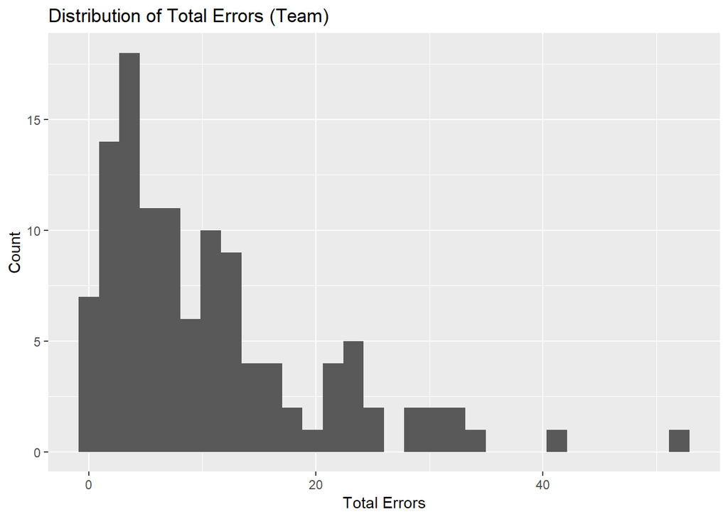

```r
y_label_team <- "Count"
x_label_team <- params$dependent_response_name_WithSpace
title_response_team <- paste("Distribution of", params$dependent_response_name_WithSpace, "(Team)")
plot_name <- paste("Histogram_", params$dependent_response_name_NoSpace, "_Team.png", sep = "")
setwd(figure_directory)

plot_data_team <- team_data %>%
  select(params$dependent_response_team, Target)

ggplot(data = plot_data_team) +
  geom_histogram(aes_string(x = params$dependent_response_team), bins = 30) +
  labs(title = title_response_team, x = x_label_team, y = y_label_team) +
  ggsave(filename = plot_name)
```

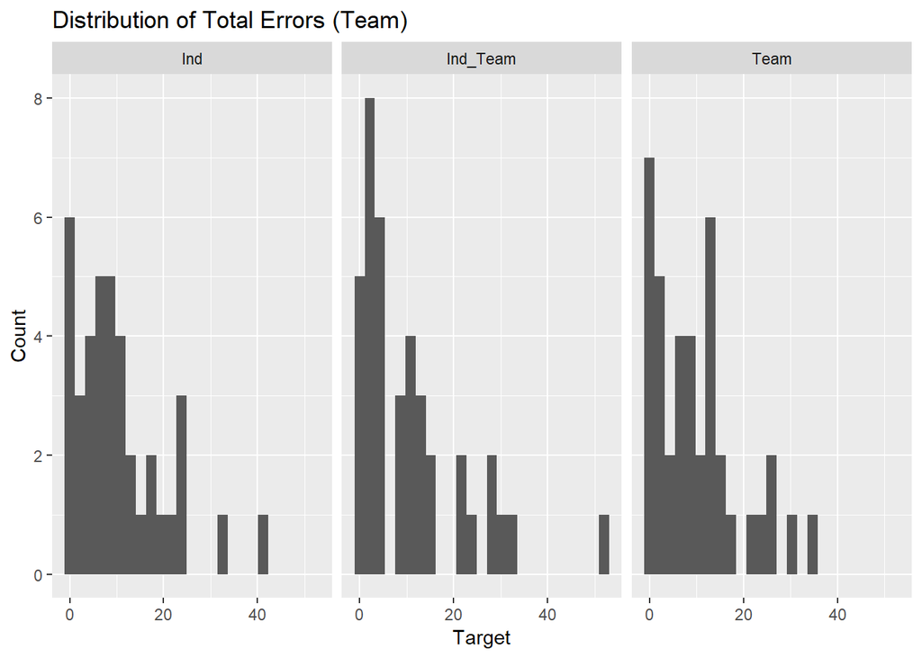

```r
y_label_team <- "Count"
x_label_team <- "Target"
title_response_team <- paste("Distribution of", params$dependent_response_name_WithSpace, "(Team)")
plot_name <- paste("Histogram_", params$dependent_response_name_NoSpace, "_ByTarget_Team.png", sep = "")
setwd(figure_directory)

plot_data_team <- team_data %>%
  select(params$dependent_response_team, Target)

ggplot(data = plot_data_team) +
  geom_histogram(aes_string(x = params$dependent_response_team), bins = 25) +
  facet_grid(. ~ Target) +
  labs(title = title_response_team, x = x_label_team, y = y_label_team) +
  ggsave(filename = plot_name)
```

```r
# Information about the N values in each condition
tableData <- team_data %>%
  group_by(Target) %>%
  summarise(N = length(.data[[params$dependent_response_team]]))

tableData %>%
  kable() %>%
  kable_styling()
```

| Target | N |
| --- | --- |
| Ind | 39 |
| Ind_Team | 39 |
| Team | 39 |

#### Individual

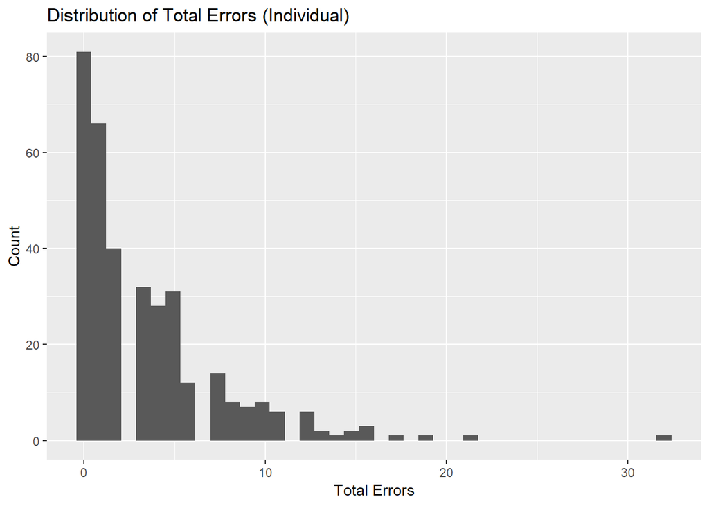

```r
y_label_ind <- "Count"
x_label_ind <- params$dependent_response_name_WithSpace
title_response_ind <- paste("Distribution of", params$dependent_response_name_WithSpace, "(Individual)")
plot_name <- paste("Histogram_", params$dependent_response_name_NoSpace, "_Ind.png", sep = "")
setwd(figure_directory)

plot_data_ind <- ind_data %>%
  select(params$dependent_response_ind, Target)

ggplot(data = plot_data_ind) +
  geom_histogram(aes_string(x = params$dependent_response_ind), bins = 40) +
  labs(title = title_response_ind, x = x_label_ind, y = y_label_ind) +
  ggsave(filename = plot_name)
```

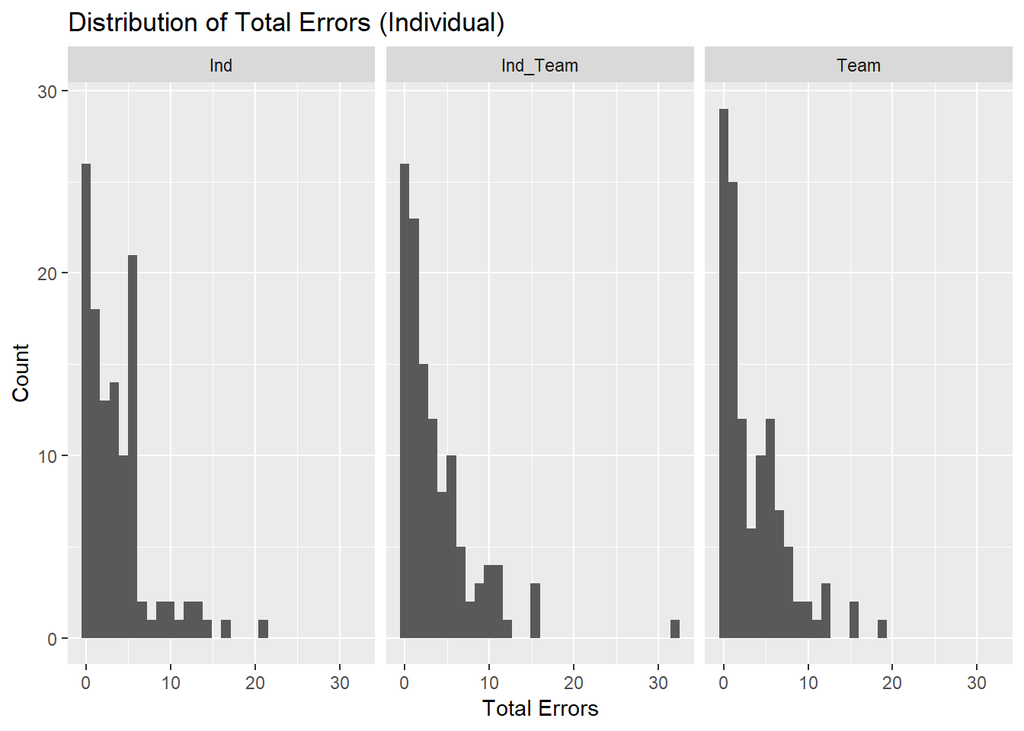

```r
y_label_ind <- "Count"
x_label_ind <- params$dependent_response_name_WithSpace
title_response_ind <- paste("Distribution of", params$dependent_response_name_WithSpace, "(Individual)")
plot_name <- paste("Histogram_", params$dependent_response_name_NoSpace, "_ByTarget_Ind.png", sep = "")
setwd(figure_directory)

plot_data_ind <- ind_data %>%
  select(params$dependent_response_ind, Target)

ggplot(data = plot_data_ind) +
  geom_histogram(aes_string(x = params$dependent_response_ind), bins = 30) +
  facet_grid(. ~ Target) +
  labs(title = title_response_ind, x = x_label_ind, y = y_label_ind) +
  ggsave(filename = plot_name)
```

```r
# Information about the N values in each condition
tableData <- ind_data %>%
  group_by(Target) %>%
  summarise(N = length(.data[[params$dependent_response_ind]]))

tableData %>%
  kable() %>%
  kable_styling()
```

| Target | N |
| --- | --- |
| Ind | 117 |
| Ind_Team | 117 |
| Team | 117 |

The distribution of the total errors continues when grouped by condition. The figures show that most participants committed less than 5 errors.

### Q: Is there exciting variation among the *Total Errors* that explains how the feedback conditions influence the *Total Errors* when session order is taken into consideration?

#### Team

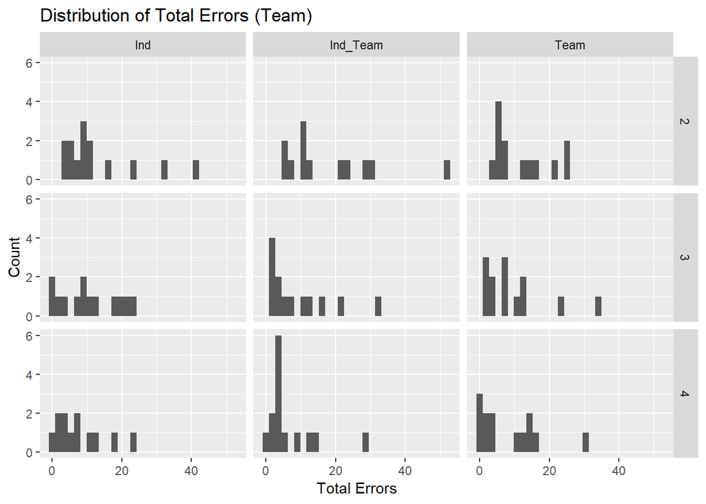

```r
y_label_team <- "Count"
x_label_team <- params$dependent_response_name_WithSpace
title_response_team <- paste("Distribution of", params$dependent_response_name_WithSpace, "(Team)")
plot_name <- paste("Histogram_", params$dependent_response_name_NoSpace, "_ByTarget_BySessionOrder_Team.png", sep = "")
setwd(figure_directory)

plot_data_team <- team_data %>%
  select(params$dependent_response_team, Target, SessionOrder)

ggplot(data = plot_data_team) +
  geom_histogram(aes_string(x = params$dependent_response_team), bins = 30) +
  labs(title = title_response_team, x = x_label_team, y = y_label_team) +
  facet_grid( SessionOrder ~ Target) +
  ggsave(filename = plot_name)
```

```r
# Information about the N values in each condition
tableData <- team_data %>%
  select(params$dependent_response_team, Target, SessionOrder) %>%
  group_by(Target, SessionOrder) %>%
  summarise(N = length(.data[[params$dependent_response_team]]))

tableData %>%
  kable() %>%
  kable_styling()
```

| Target | SessionOrder | N |
| --- | --- | --- |
| Ind | 2 | 14 |
| Ind | 3 | 13 |
| Ind | 4 | 12 |
| Ind_Team | 2 | 12 |
| Ind_Team | 3 | 13 |
| Ind_Team | 4 | 14 |
| Team | 2 | 13 |
| Team | 3 | 13 |
| Team | 4 | 13 |

Overall, it looks as though each condition has a similar pattern. In each condition, over time, the skew in the data moves to the left. In other words, less and less errors are committed over time.

#### Individual

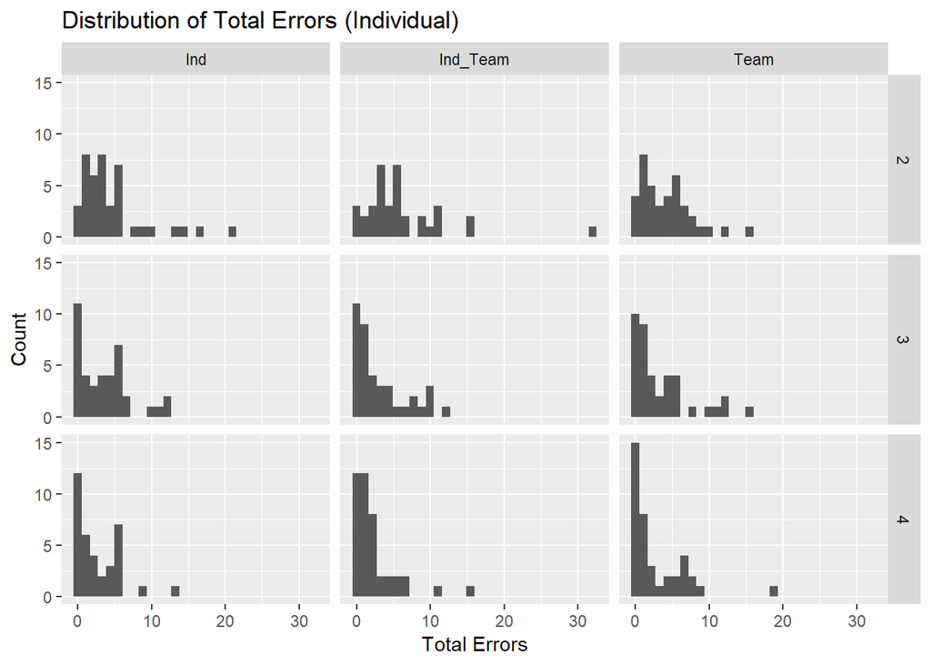

```r
y_label_ind <- "Count"
x_label_ind <- params$dependent_response_name_WithSpace
title_response_ind <- paste("Distribution of", params$dependent_response_name_WithSpace, "(Individual)")
plot_name <- paste("Histogram_", params$dependent_response_name_NoSpace, "_ByTarget_BySessionOrder_Ind.png", sep = "")
setwd(figure_directory)

plot_data_ind <- ind_data %>%
  select(params$dependent_response_ind, Target, SessionOrder)

ggplot(data = plot_data_ind) +
  geom_histogram(aes_string(x = params$dependent_response_ind), bins = 30) +
  facet_grid(SessionOrder ~ Target) +
  labs(title = title_response_ind, x = x_label_ind, y = y_label_ind) +
  ggsave(filename = plot_name)
```

```r
# Information about the N values in each condition
tableData <- ind_data %>%
  select(params$dependent_response_ind, Target, SessionOrder) %>%
  group_by(Target, SessionOrder) %>%
  summarise(N = length(.data[[params$dependent_response_ind]]))

tableData %>%
  kable() %>%
  kable_styling()
```

| Target | SessionOrder | N |
| --- | --- | --- |
| Ind | 2 | 42 |
| Ind | 3 | 39 |
| Ind | 4 | 36 |
| Ind_Team | 2 | 36 |
| Ind_Team | 3 | 39 |
| Ind_Team | 4 | 42 |
| Team | 2 | 39 |
| Team | 3 | 39 |
| Team | 4 | 39 |

Overall, the results show that the skew in the data happens over time in each group. I do want to note that in session 4 and the Team condition, there is a high bar around the 0 errors, suggesting that individuals committed less error in session 4 when given team feedback.

#### Summary / Reflection

Overall, there are no unexpected trends in the distribution of the data overall, and when the data is grouped by condition. There is also no surprising trend when viewing the data over time (i.e., from session to session).

### Q: Is there an *interaction* between the Target and Session Order for the *Total Errors*?

I am interested in this question for modeling purposes. I want to know if I need to include the interaction between Target and Session Order.

#### Team

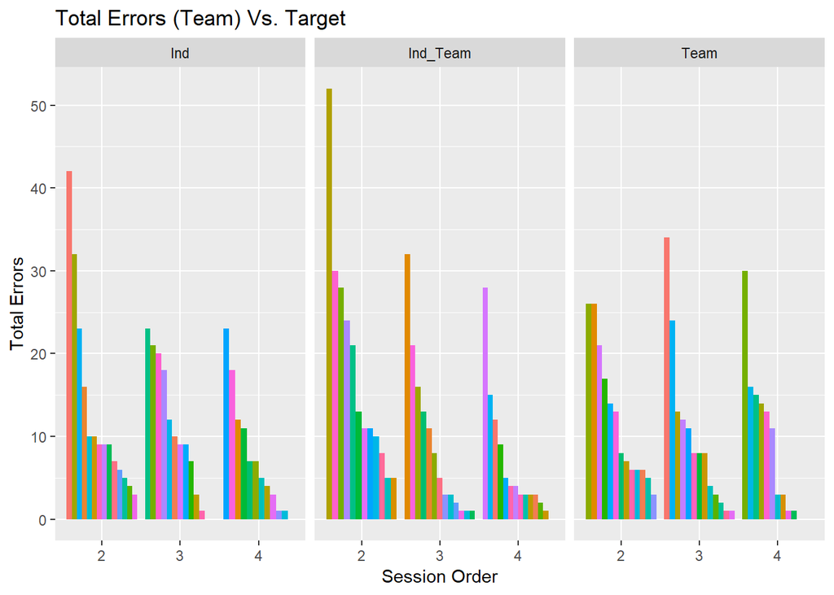

```r
y_label_team <- params$dependent_response_name_WithSpace
x_label_team <- "Session Order"
title_response_team <- paste(params$dependent_response_name_WithSpace, "(Team) Vs. Target")
plot_name <- paste("Bar_", params$dependent_response_name_NoSpace, "_ByTarget_BySessionOrder_Team.png", sep = "")
setwd(figure_directory)

plot_data_team <- team_data %>%
  select(Target, SessionOrder, params$dependent_response_team, Team) %>%
  mutate(rank_order = -rank(team_data[[params$dependent_response_team]], ties.method = "first"))

ggplot(data = plot_data_team,
       aes(x = factor(SessionOrder),
                  y = .data[[params$dependent_response_team]],
                  fill = Team,
                  group = rank_order)) +
  geom_bar(stat = "identity", position = "dodge") +
  facet_grid(. ~ Target) +
  guides(fill = FALSE) +
  labs(y = y_label_team, x = x_label_team, title = title_response_team, fill = "Teams") +
  ggsave(filename = plot_name)
```

```r
sumDataCount <- plot_data_team %>%
  group_by(Target, SessionOrder) %>%
  summarise(N = length(.data[[params$dependent_response_team]]))

sumDataCount %>%
  kable() %>%
  kable_styling()
```

| Target | SessionOrder | N |
| --- | --- | --- |
| Ind | 2 | 14 |
| Ind | 3 | 13 |
| Ind | 4 | 12 |
| Ind_Team | 2 | 12 |
| Ind_Team | 3 | 13 |
| Ind_Team | 4 | 14 |
| Team | 2 | 13 |
| Team | 3 | 13 |
| Team | 4 | 13 |

Something that jumps out at me is the bars in session 4. It looks as though the bars in session 4 for the Ind_Team condition drop off quicker than the Team and Ind condition. Outside of that, the trends for each group look similar.

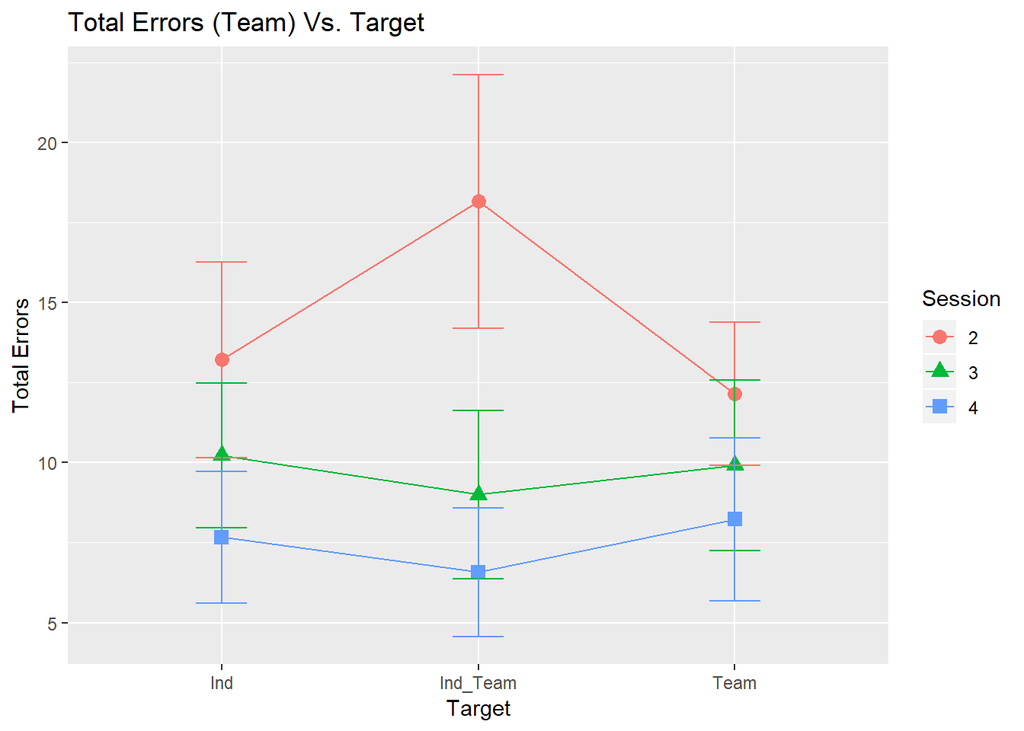

```r
y_label_team <- params$dependent_response_name_WithSpace
x_label_team <- "Target"
title_response_team <- paste(params$dependent_response_name_WithSpace, "(Team) Vs. Target")
plot_name <- paste("InteractionPlot_", params$dependent_response_name_NoSpace, "_ByTarget_BySessionOrder_Team.png", sep = "")
setwd(figure_directory)

plot_data_team <- team_data %>%
  select(Target, SessionOrder, params$dependent_response_team) %>%
  group_by(SessionOrder, Target) %>%
  summarise(dependentAverage = mean(.data[[params$dependent_response_team]]),
            Stdv =sd(.data[[params$dependent_response_team]]), n = length(.data[[params$dependent_response_team]]),
            StEr = sd(.data[[params$dependent_response_team]]) / sqrt(length(.data[[params$dependent_response_team]])))

ggplot(data = plot_data_team, aes(x = Target, y = dependentAverage, color = SessionOrder, shape = SessionOrder)) +
  geom_point(size = 3) +
  geom_line(aes(group=SessionOrder, color = SessionOrder)) +
  geom_errorbar(aes(ymin = dependentAverage - StEr, ymax = dependentAverage + StEr), width = 0.2) +
  labs(y = y_label_team, x = x_label_team, title = title_response_team, color = "Session", shape = "Session") +
  ggsave(filename = plot_name)
```

The plot indicates that there may be no interaction between Target and Session Order.

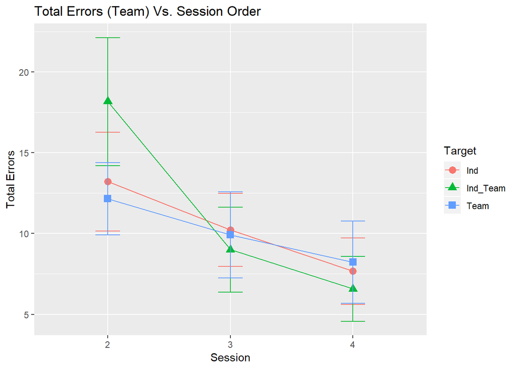

```r
y_label_team <- params$dependent_response_name_WithSpace
x_label_team <- "Session"
title_response_team <- paste(params$dependent_response_name_WithSpace, "(Team) Vs. Session Order")
plot_name <- paste("InteractionPlot_", params$dependent_response_name_NoSpace, "_BySessionOrder_ByTarget_Team.png", sep = "")
setwd(figure_directory)

plot_data_team <- team_data %>%
  select(Target, SessionOrder, params$dependent_response_team) %>%
  group_by(SessionOrder, Target) %>%
  summarise(DependentAverage = mean(.data[[params$dependent_response_team]]),
            Stdv =sd(.data[[params$dependent_response_team]]), n = length(.data[[params$dependent_response_team]]),
            StEr = sd(.data[[params$dependent_response_team]]) / sqrt(length(.data[[params$dependent_response_team]])))

ggplot(data = plot_data_team, aes(x = SessionOrder , y = DependentAverage, color = Target, shape = Target)) +
  geom_point(size = 3) +
  geom_line(aes(group=Target, color = Target)) +
  geom_errorbar(aes(ymin = DependentAverage - StEr, ymax = DependentAverage + StEr), width = 0.2) +
  labs(y = y_label_team, x = x_label_team, title = title_response_team, color = "Target", shape = "Target") +
  ggsave(filename = plot_name)
```

Overall, it looks like there is no interaction between Target and Session Order. I am not expecting to find any significance in later analysis.

#### Individual

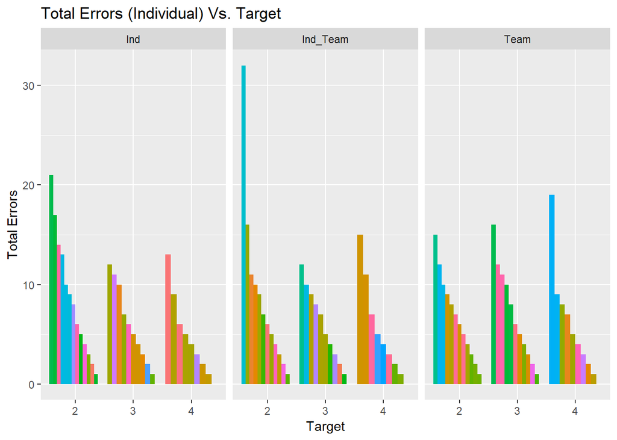

```r
y_label_ind <- params$dependent_response_name_WithSpace
x_label_ind <- "Target"
title_response_ind <- paste(params$dependent_response_name_WithSpace,"(Individual) Vs. Target")
plot_name <- paste("Bar_", params$dependent_response_name_NoSpace, "_ByTarget_BySessionOrder_Ind.png", sep = "")
setwd(figure_directory)

plot_data_ind <- ind_data %>%
  select(Target, SessionOrder, params$dependent_response_ind, Player_ID) %>%
  mutate(rank_order = -rank(.data[[params$dependent_response_ind]]))

ggplot(data = plot_data_ind,
       aes(x = factor(SessionOrder),
                  y = .data[[params$dependent_response_ind]],
                  fill = Player_ID, group = rank_order )) +
  geom_bar(stat = "identity", position = "dodge") +
  facet_grid(. ~ Target) +
  guides(fill = FALSE) +
  labs(y = y_label_ind, x = x_label_ind, title = title_response_ind, fill = "Player_ID") +
  ggsave(filename = plot_name)
```

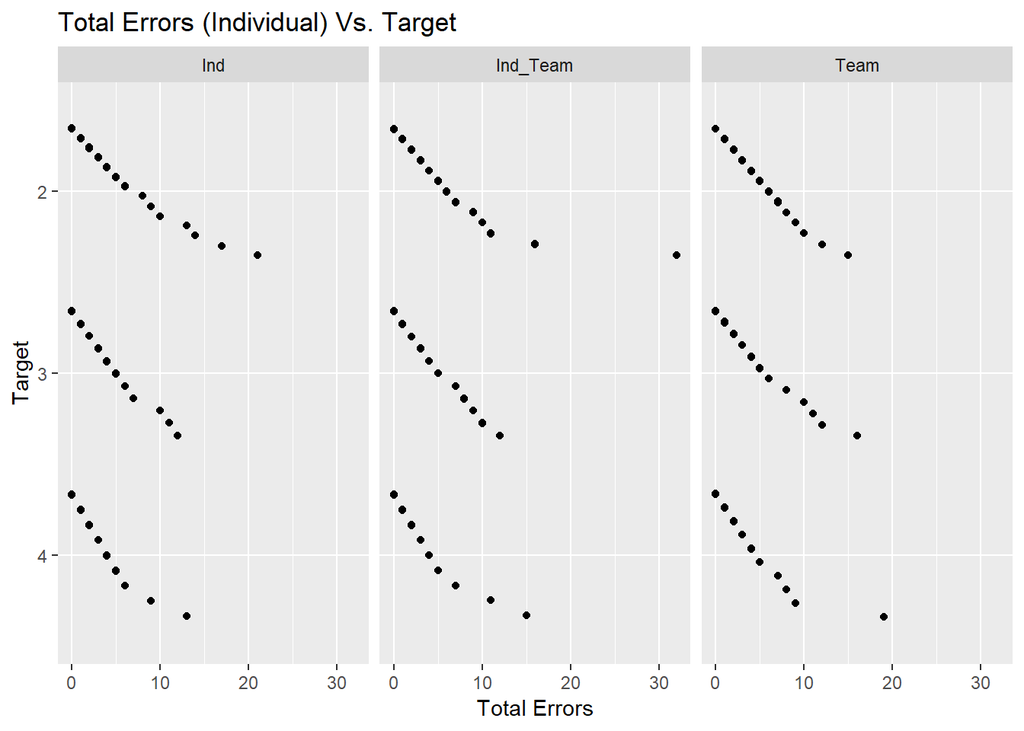

```r
ggplot(data = plot_data_ind,
       aes(x = factor(SessionOrder),
           y = .data[[params$dependent_response_ind]],
           fill = Player_ID, group = rank_order)) +
  geom_point(position = position_jitterdodge()) +
  facet_grid(. ~ Target) +
  guides(fill = FALSE) +
  coord_flip()+
  xlim("4", "3", "2") +
  labs(y = y_label_ind, x = x_label_ind, title = title_response_ind, fill = "Player ID") +
  ggsave(filename = paste("Point_", params$dependent_response_name_NoSpace, "_ByTarget_BySessionOrder_Ind.png", sep = ""), width = 10)
```

```r
sumDataCount <- plot_data_ind %>%
  group_by(Target, SessionOrder) %>%
  summarise(N = length(.data[[params$dependent_response_ind]]))

sumDataCount %>%
  kable() %>%
  kable_styling()
```

| Target | SessionOrder | N |
| --- | --- | --- |
| Ind | 2 | 42 |
| Ind | 3 | 39 |
| Ind | 4 | 36 |
| Ind_Team | 2 | 36 |
| Ind_Team | 3 | 39 |
| Ind_Team | 4 | 42 |
| Team | 2 | 39 |
| Team | 3 | 39 |
| Team | 4 | 39 |

Overall, no noticeable pattern would lead me to believe there is a strong interaction between the two variables, Target and Session Order.

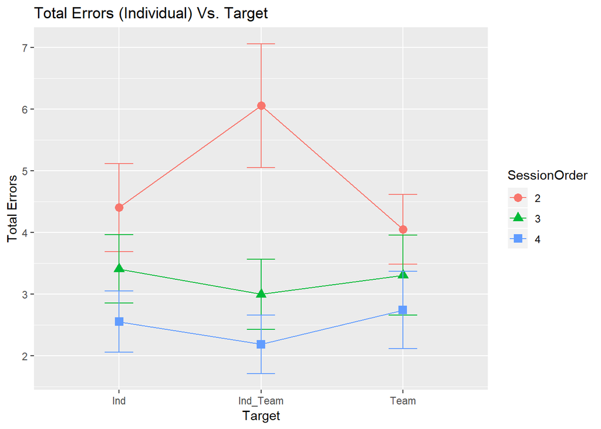

```r
y_label_ind <- params$dependent_response_name_WithSpace
x_label_ind <- "Target"
title_response_ind <- paste(params$dependent_response_name_WithSpace, "(Individual) Vs. Target")
plot_name <- paste("InteractionPlot_", params$dependent_response_name_NoSpace, "_ByTarget_BySessionOrder_Ind.png", sep = "")
setwd(figure_directory)

plot_data_ind <- ind_data %>%
  select(Target, SessionOrder, params$dependent_response_ind) %>%
  group_by(SessionOrder, Target) %>%
  summarise(Average = mean(.data[[params$dependent_response_ind]]),
            Stdv =sd(.data[[params$dependent_response_ind]]),
            n = length(.data[[params$dependent_response_ind]]),
            StEr = sd(.data[[params$dependent_response_ind]]) / sqrt(length(.data[[params$dependent_response_ind]])))

ggplot(data = plot_data_ind, aes(x = Target, y = Average, color = SessionOrder, shape=SessionOrder)) +
  geom_point(size = 3) +
  geom_line(aes(group=SessionOrder, color = SessionOrder)) +
  geom_errorbar(aes(ymin = Average - StEr, ymax = Average + StEr), width = 0.2) +
  labs(y = y_label_ind, x = x_label_ind, title = title_response_ind, fill = "Players") +
  ggsave(filename = plot_name)
```

Visually, there seems to be no interaction between Target and Session Order.

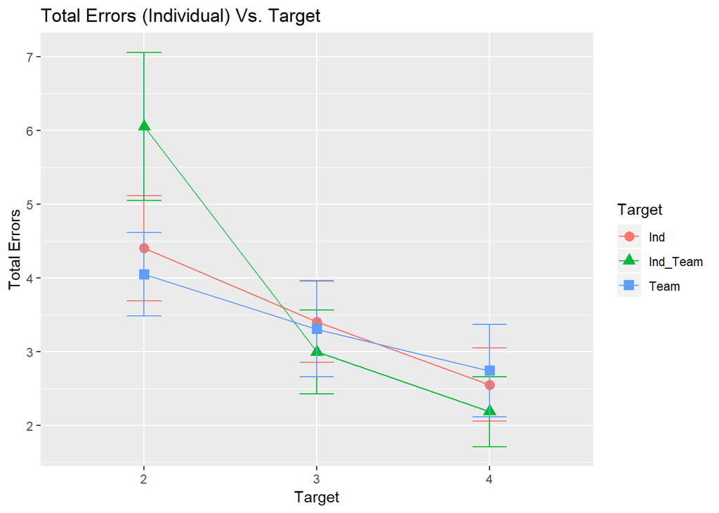

```r
y_label_ind <- params$dependent_response_name_WithSpace
x_label_ind <- "Target"
title_response_ind <- paste(params$dependent_response_name_WithSpace, "(Individual) Vs. Target")
plot_name <- paste("InteractionPlot_", params$dependent_response_name_NoSpace, "_BySessionOrder_ByTarget_Ind.png", sep = "")
setwd(figure_directory)

plot_data_ind <- ind_data %>%
  select(Target, SessionOrder, params$dependent_response_ind) %>%
  group_by(SessionOrder, Target) %>%
  summarise(Average = mean(.data[[params$dependent_response_ind]]),
            Stdv =sd(.data[[params$dependent_response_ind]]),
            n = length(.data[[params$dependent_response_ind]]),
            StEr = sd(.data[[params$dependent_response_ind]]) / sqrt(length(.data[[params$dependent_response_ind]])))

ggplot(data = plot_data_ind, aes(x = SessionOrder, y = Average, color = Target, shape=Target)) +
  geom_point(size = 3) +
  geom_line(aes(group=Target, color = Target)) +
  geom_errorbar(aes(ymin = Average - StEr, ymax = Average + StEr), width = 0.2) +
  labs(y = y_label_ind, x = x_label_ind, title = title_response_ind, fill = "Players") +
  ggsave(filename = plot_name)
```

Visually, there seems to be no interaction between Target and Session Order.

#### Summary / Reflection

Overall, there seems to be no interaction between Target and Session Order at the individual or team level. The patterns and averages all seem to be similar, and I am expecting further analysis to show no significant findings.

### Q: Is there an interaction between the Target and Session Order for the *Total Errors* that is statistically significant?

I am interested in determining if a linear mixed effect model should include the interaction effect between the Target and Session Order variable.

A note on the effect size ($R^2$). This method generates two types of ($R^2$) values called marginal ($R_{m}^2$) and conditional ($R_{c}^2$) effect size. The $R_{m}^2$ calculates how much of the variance is described by the fixed effect variables (feedback condition and session order) while the $R_{c}^2$ calculates how much of the variance is described by both the fixed and random effect variables.

#### Full Models Used for Team and Individual

The next two sections below describe the full model for team and individual level analysis. Five models were fitted and then compared. One model was the null model, one model was the full model, and the last three are a subset of the full model.

##### Team Full Model

$$y_{ijt} = \mu + \alpha_{i} + \beta_{j} + \alpha_{i} \beta_{j} + \gamma_{t} + \epsilon_{ijt}$$

##### Individual Team Full Model

$$y_{ijtp} = \mu + \alpha_{i} + \beta_{j} + \alpha_{i} \beta_{j} + \gamma_{t} + \theta_{p} + \epsilon_{ijtp}$$

#### Team

```r
# Data to fit
data_modified_team <- team_data %>%
  select(TeamScore,
         params$dependent_response_team,
         Target,
         SessionOrder,
         Team)

# Generate models with variable response
data_focus_team <- data_modified_team
model.null <- model_data_Target_Session(df = data_focus_team, dependent =  params$dependent_response_team, model.type =  "null", is.team = TRUE, is.robust =FALSE)
model.All <- model_data_Target_Session(df = data_focus_team, dependent =  params$dependent_response_team, model.type =  "All", is.team = TRUE, is.robust = FALSE)
model.NoInteraction <- model_data_Target_Session(df = data_focus_team, dependent =  params$dependent_response_team, model.type =  "NoInteraction", is.team = TRUE, is.robust = FALSE)
model.NoInteraction.NoTarget <- model_data_Target_Session(df = data_focus_team, dependent =  params$dependent_response_team, model.type =  "NoInteraction_NoTarget", is.team = TRUE, is.robust = FALSE)
model.NoInteraction.NoSession <- model_data_Target_Session(df = data_focus_team, dependent =  params$dependent_response_team, model.type =  "NoInteraction_NoSession", is.team = TRUE, is.robust = FALSE)

# There is an option to compare all the models with the anova(). However, the function does not compare all models to model.null
anova(model.null,
      model.All) %>%
  kable(caption = "ANOVA: Null and All") %>%
  kable_styling()
```

```
## refitting model(s) with ML (instead of REML)
```

ANOVA: Null and All

|  | Df | AIC | BIC | logLik | deviance | Chisq | Chi Df | Pr(>Chisq) |
| --- | --- | --- | --- | --- | --- | --- | --- | --- |
| model.null | 3 | 845.0862 | 853.3727 | -419.5431 | 839.0862 | NA | NA | NA |
| model.All | 11 | 835.2635 | 865.6474 | -406.6317 | 813.2635 | 25.8227 | 8 | 0.0011262 |

```r
anova(model.null,
      model.NoInteraction) %>%
  kable(caption = "ANOVA: Null and No.Interaction") %>%
  kable_styling()
```

```
## refitting model(s) with ML (instead of REML)
```

ANOVA: Null and No.Interaction

|  | Df | AIC | BIC | logLik | deviance | Chisq | Chi Df | Pr(>Chisq) |
| --- | --- | --- | --- | --- | --- | --- | --- | --- |
| model.null | 3 | 845.0862 | 853.3727 | -419.5431 | 839.0862 | NA | NA | NA |
| model.NoInteraction | 7 | 829.3801 | 848.7153 | -407.6900 | 815.3801 | 23.70608 | 4 | 9.15e-05 |

```r
anova(model.null,
      model.NoInteraction.NoTarget) %>%
  kable(caption = "ANOVA: Null and No.Interaction.No.Target") %>%
  kable_styling()
```

```
## refitting model(s) with ML (instead of REML)
```

ANOVA: Null and No.Interaction.No.Target

|  | Df | AIC | BIC | logLik | deviance | Chisq | Chi Df | Pr(>Chisq) |
| --- | --- | --- | --- | --- | --- | --- | --- | --- |
| model.null | 3 | 845.0862 | 853.3727 | -419.5431 | 839.0862 | NA | NA | NA |
| model.NoInteraction.NoTarget | 5 | 826.0039 | 839.8147 | -408.0019 | 816.0039 | 23.08229 | 2 | 9.7e-06 |

```r
anova(model.null,
      model.NoInteraction.NoSession) %>%
  kable(caption = "ANOVA: Null and No.Interaction.No.Session") %>%
  kable_styling()
```

```
## refitting model(s) with ML (instead of REML)
```

ANOVA: Null and No.Interaction.No.Session

|  | Df | AIC | BIC | logLik | deviance | Chisq | Chi Df | Pr(>Chisq) |
| --- | --- | --- | --- | --- | --- | --- | --- | --- |
| model.null | 3 | 845.0862 | 853.3727 | -419.5431 | 839.0862 | NA | NA | NA |
| model.NoInteraction.NoSession | 5 | 848.7987 | 862.6095 | -419.3993 | 838.7987 | 0.2874979 | 2 | 0.8661051 |

The following models were significantly different from the null model: model.All, model.NoInteraction, model.NoInteraction.NoTarget.

model.All: Session Order, Target, and the interaction are included in this model.

model.NoInteraction: Session order and target are the fixed effects in this model.

model.NoInteraction.NoTarget: Session order is the only fixed effect in this model.

```r
# Data to fit
data_modified_team <- team_data %>%
  select(TeamScore,
         params$dependent_response_team,
         Target,
         SessionOrder,
         Team)

# Generate models with variable response
data_focus_team <- data_modified_team
model.All <- model_data_Target_Session(df = data_focus_team, dependent =  params$dependent_response_team, model.type =  "All", is.team = TRUE, is.robust = FALSE)
model.NoInteraction <- model_data_Target_Session(df = data_focus_team, dependent =  params$dependent_response_team, model.type =  "NoInteraction", is.team = TRUE, is.robust = FALSE)
model.NoInteraction.NoTarget <- model_data_Target_Session(df = data_focus_team, dependent =  params$dependent_response_team, model.type =  "NoInteraction_NoTarget", is.team = TRUE, is.robust = FALSE)

# Compare all of the models
anova(model.All,
      model.NoInteraction) %>%
  kable(caption = "ANOVA: model.All and model.NoInteraction") %>%
  kable_styling()
```

```
## refitting model(s) with ML (instead of REML)
```

ANOVA: model.All and model.NoInteraction

|  | Df | AIC | BIC | logLik | deviance | Chisq | Chi Df | Pr(>Chisq) |
| --- | --- | --- | --- | --- | --- | --- | --- | --- |
| model.NoInteraction | 7 | 829.3801 | 848.7153 | -407.6900 | 815.3801 | NA | NA | NA |
| model.All | 11 | 835.2635 | 865.6474 | -406.6317 | 813.2635 | 2.116621 | 4 | 0.7143194 |

```r
anova(model.All,
      model.NoInteraction.NoTarget) %>%
  kable(caption = "ANOVA: model.All and model.NoInteraction.NoTarget") %>%
  kable_styling()
```

```
## refitting model(s) with ML (instead of REML)
```

ANOVA: model.All and model.NoInteraction.NoTarget

|  | Df | AIC | BIC | logLik | deviance | Chisq | Chi Df | Pr(>Chisq) |
| --- | --- | --- | --- | --- | --- | --- | --- | --- |
| model.NoInteraction.NoTarget | 5 | 826.0039 | 839.8147 | -408.0019 | 816.0039 | NA | NA | NA |
| model.All | 11 | 835.2635 | 865.6474 | -406.6317 | 813.2635 | 2.740412 | 6 | 0.840651 |

```r
anova(model.NoInteraction,
      model.NoInteraction.NoTarget) %>%
  kable(caption = "ANOVA: model.NoInteraction and model.NoInteraction.NoTarget") %>%
  kable_styling()
```

```
## refitting model(s) with ML (instead of REML)
```

ANOVA: model.NoInteraction and model.NoInteraction.NoTarget

|  | Df | AIC | BIC | logLik | deviance | Chisq | Chi Df | Pr(>Chisq) |
| --- | --- | --- | --- | --- | --- | --- | --- | --- |
| model.NoInteraction.NoTarget | 5 | 826.0039 | 839.8147 | -408.0019 | 816.0039 | NA | NA | NA |
| model.NoInteraction | 7 | 829.3801 | 848.7153 | -407.6900 | 815.3801 | 0.6237912 | 2 | 0.732058 |

Overall, the results indicate that model.All is no significantly better than model.NoInteraction or model.NoInteraction.NoTarget. This suggests that we can assume no interaction. It is important to note that while the difference in AIC values when comparing model.All to model.NoInteraction and model.NoInteraction.NoTarget is small; the BIC difference is large.

The results also indicate that there is no significant difference between model.NoInteraction or model.NoInteraction.NoTarget. In other words, the extra Target term does not improve the model. However, the AIC and BIC value are close in number (less than 10 difference), which is not a great indication that model.NoInteraction.NoTarget is better that much better than model.NoInteraction. I will look at the effect sizes to examine the differences.

```r
# Data to fit
data_modified_team <- team_data %>%
  select(TeamScore,
         params$dependent_response_team,
         Target,
         SessionOrder,
         Team)

# Generate models with variable response
#response_variable <- "timeRemaining_team"
data_focus_team <- data_modified_team

model.NoInteraction <- model_data_Target_Session(df = data_focus_team, dependent =  params$dependent_response_team, model.type =  "NoInteraction", is.team = TRUE, is.robust = FALSE)
model.NoInteraction.NoTarget <- model_data_Target_Session(df = data_focus_team, dependent =  params$dependent_response_team, model.type =  "NoInteraction_NoTarget", is.team = TRUE, is.robust = FALSE)

# Effect size (R^2)

r.squaredGLMM(model.NoInteraction.NoTarget) %>%
  kable(caption = "Table: Effect size for *No Interaction and No Target*") %>%
   kable_styling(full_width = F)
```

Table: Effect size for *No Interaction and No Target*

| R2m | R2c |
| --- | --- |
| 0.0862898 | 0.6175485 |

```r
r.squaredGLMM(model.NoInteraction) %>%
  kable(caption = "Table: Effect size for *No Interaction*") %>%
   kable_styling(full_width = F)
```

Table: Effect size for *No Interaction*

| R2m | R2c |
| --- | --- |
| 0.0876893 | 0.6129728 |

The results show a small difference in both effect sizes.

**Reflection:** Overal, **model.NoInteraction** and **model.NoInteraction.NoTarget** seem to do a similar job at explaining the variance within the data. If I had to rely solely on the numbers, **model.NoInteraction.NoTarget** has an advantage over **model.NoInteraction**. However, I cannot definitively say one model is better than the other. I will include **model.NoInteraction** and **model.NoInteraction.NoTarget** in further team analysis.

#### Individual

```r
# Data to model
data_modified_ind <- ind_data %>%
  select(params$dependent_response_ind,
         Target,
         SessionOrder,
         Team,
         Player_ID)

data_focus_ind <- data_modified_ind
model.null <- model_data_Target_Session(df = data_focus_ind, dependent =  params$dependent_response_ind, model.type =  "null", is.team = FALSE, is.robust = FALSE)
model.All <- model_data_Target_Session(df = data_focus_ind, dependent =  params$dependent_response_ind, model.type =  "All", is.team = FALSE, is.robust = FALSE)
model.NoInteraction <- model_data_Target_Session(df = data_focus_ind, dependent =  params$dependent_response_ind, model.type =  "NoInteraction", is.team = FALSE, is.robust = FALSE)
model.NoInteraction.NoTarget <- model_data_Target_Session(df = data_focus_ind, dependent =  params$dependent_response_ind, model.type =  "NoInteraction_NoTarget", is.team = FALSE, is.robust = FALSE)
model.NoInteraction.NoSession <- model_data_Target_Session(df = data_focus_ind, dependent =  params$dependent_response_ind, model.type =  "NoInteraction_NoSession", is.team = FALSE, is.robust = FALSE)

# There is an option to compare all the models with the anova(). However, the function does not compare all models to model.null
anova(model.null,
      model.All) %>%
  kable(caption = "ANOVA: model.null and model.All") %>%
  kable_styling()
```

```
## refitting model(s) with ML (instead of REML)
```

ANOVA: model.null and model.All

|  | Df | AIC | BIC | logLik | deviance | Chisq | Chi Df | Pr(>Chisq) |
| --- | --- | --- | --- | --- | --- | --- | --- | --- |
| model.null | 4 | 1911.768 | 1927.211 | -951.8841 | 1903.768 | NA | NA | NA |
| model.All | 12 | 1889.886 | 1936.215 | -932.9428 | 1865.886 | 37.88259 | 8 | 7.9e-06 |

```r
anova(model.null,
      model.NoInteraction) %>%
  kable(caption = "ANOVA: model.null and model.NoInteraction") %>%
  kable_styling()
```

```
## refitting model(s) with ML (instead of REML)
```

ANOVA: model.null and model.NoInteraction

|  | Df | AIC | BIC | logLik | deviance | Chisq | Chi Df | Pr(>Chisq) |
| --- | --- | --- | --- | --- | --- | --- | --- | --- |
| model.null | 4 | 1911.768 | 1927.211 | -951.8841 | 1903.768 | NA | NA | NA |
| model.NoInteraction | 8 | 1884.688 | 1915.574 | -934.3439 | 1868.688 | 35.08047 | 4 | 4e-07 |

```r
anova(model.null,
      model.NoInteraction.NoTarget) %>%
  kable(caption = "ANOVA: model.null and model.NoInteraction.NoTarget") %>%
  kable_styling()
```

```
## refitting model(s) with ML (instead of REML)
```

ANOVA: model.null and model.NoInteraction.NoTarget

|  | Df | AIC | BIC | logLik | deviance | Chisq | Chi Df | Pr(>Chisq) |
| --- | --- | --- | --- | --- | --- | --- | --- | --- |
| model.null | 4 | 1911.768 | 1927.211 | -951.8841 | 1903.768 | NA | NA | NA |
| model.NoInteraction.NoTarget | 6 | 1881.542 | 1904.707 | -934.7709 | 1869.542 | 34.22642 | 2 | 0 |

```r
anova(model.null,
      model.NoInteraction.NoSession) %>%
  kable(caption = "ANOVA: model.null and model.NoInteraction.NoSession") %>%
  kable_styling()
```

```
## refitting model(s) with ML (instead of REML)
```

ANOVA: model.null and model.NoInteraction.NoSession

|  | Df | AIC | BIC | logLik | deviance | Chisq | Chi Df | Pr(>Chisq) |
| --- | --- | --- | --- | --- | --- | --- | --- | --- |
| model.null | 4 | 1911.768 | 1927.211 | -951.8841 | 1903.768 | NA | NA | NA |
| model.NoInteraction.NoSession | 6 | 1915.310 | 1938.475 | -951.6552 | 1903.310 | 0.4577662 | 2 | 0.7954215 |

The following models were significantly different from the null model: model.All, model.NoInteraction, model.NoInteraction.NoTarget.

model.All: Session Order, Target, and the interaction are included in this model.

model.NoInteraction: Session order and target are the fixed effects in this model.

model.NoInteraction.NoTarget: Session order is the only fixed effect in this model.

```r
# Data to model
data_modified_ind <- ind_data %>%
  select(params$dependent_response_ind,
         Target,
         SessionOrder,
         Team,
         Player_ID)

data_focus_ind <- data_modified_ind
model.All <- model_data_Target_Session(df = data_focus_ind, dependent =  params$dependent_response_ind, model.type =  "All", is.team = FALSE, is.robust = FALSE)
model.NoInteraction <- model_data_Target_Session(df = data_focus_ind, dependent =  params$dependent_response_ind, model.type =  "NoInteraction", is.team = FALSE, is.robust = FALSE)
model.NoInteraction.NoTarget <- model_data_Target_Session(df = data_focus_ind, dependent =  params$dependent_response_ind, model.type =  "NoInteraction_NoTarget", is.team = FALSE, is.robust = FALSE)

anova(model.All,
      model.NoInteraction) %>%
  kable(caption = "ANOVA: All and No.Interaction") %>%
  kable_styling()
```

```
## refitting model(s) with ML (instead of REML)
```

ANOVA: All and No.Interaction

|  | Df | AIC | BIC | logLik | deviance | Chisq | Chi Df | Pr(>Chisq) |
| --- | --- | --- | --- | --- | --- | --- | --- | --- |
| model.NoInteraction | 8 | 1884.688 | 1915.574 | -934.3439 | 1868.688 | NA | NA | NA |
| model.All | 12 | 1889.886 | 1936.215 | -932.9428 | 1865.886 | 2.802122 | 4 | 0.5914665 |

```r
anova(model.All,
      model.NoInteraction.NoTarget) %>%
  kable(caption = "ANOVA: All and NoInteraction.NoTarget") %>%
  kable_styling()
```

```
## refitting model(s) with ML (instead of REML)
```

ANOVA: All and NoInteraction.NoTarget

|  | Df | AIC | BIC | logLik | deviance | Chisq | Chi Df | Pr(>Chisq) |
| --- | --- | --- | --- | --- | --- | --- | --- | --- |
| model.NoInteraction.NoTarget | 6 | 1881.542 | 1904.707 | -934.7709 | 1869.542 | NA | NA | NA |
| model.All | 12 | 1889.886 | 1936.215 | -932.9428 | 1865.886 | 3.656173 | 6 | 0.7230888 |

```r
anova(model.NoInteraction,
      model.NoInteraction.NoTarget) %>%
  kable(caption = "ANOVA: No.Interaction and NoInteraction.NoTarget") %>%
  kable_styling()
```

```
## refitting model(s) with ML (instead of REML)
```

ANOVA: No.Interaction and NoInteraction.NoTarget

|  | Df | AIC | BIC | logLik | deviance | Chisq | Chi Df | Pr(>Chisq) |
| --- | --- | --- | --- | --- | --- | --- | --- | --- |
| model.NoInteraction.NoTarget | 6 | 1881.542 | 1904.707 | -934.7709 | 1869.542 | NA | NA | NA |
| model.NoInteraction | 8 | 1884.688 | 1915.574 | -934.3439 | 1868.688 | 0.8540514 | 2 | 0.6524468 |

Overall, the data shows that the model.All is not significantly better that the models without the interaction. This suggests that we do not need to include the interaction in the model. It is important to note that the difference in AIC values are small when comparing the model.ALL to NoInteraction.NoTarget and NoInteraction but the BIC values are larger.

The **model.NoInteraction** is not signficantly better than **model.NoInteraction.NoTarget**. It is important to note that the AIC and BIC values are simliar (i.e., less than 11 difference). I want to examine the effect size to see if there are any major differences

```r
# Data to model
data_modified_ind <- ind_data %>%
  select(params$dependent_response_ind,
         Target,
         SessionOrder,
         Team,
         Player_ID)

data_focus_ind <- data_modified_ind
model.NoInteraction.NoTarget <- model_data_Target_Session(df = data_focus_ind, dependent =  params$dependent_response_ind, model.type =  "NoInteraction_NoTarget", is.team = FALSE, is.robust = FALSE)
model.NoInteraction <- model_data_Target_Session(df = data_focus_ind, dependent =  params$dependent_response_ind, model.type =  "NoInteraction", is.team = FALSE, is.robust = FALSE)

# Effect size (R^2)

r.squaredGLMM(model.NoInteraction) %>%
  kable(caption = "Table: Effect size for *No Interaction*") %>%
   kable_styling(full_width = F)
```

Table: Effect size for *No Interaction*

| R2m | R2c |
| --- | --- |
| 0.0556664 | 0.4762512 |

```r
r.squaredGLMM(model.NoInteraction.NoTarget) %>%
  kable(caption = "Table: Effect size for *No Interaction No Target*") %>%
   kable_styling(full_width = F)
```

Table: Effect size for *No Interaction No Target*

| R2m | R2c |
| --- | --- |
| 0.0545719 | 0.4772972 |

The results show that both **model.NoInteraction** and **model.NoInteraction.NoTarget** describe a similar amount of the varience.

#### Summary / Reflection

Untlimatly, the results suggest that **model.NoInteraction** and **model.NoInteraction.NoTarget** do the best job at describing the data at the individual and team level. Common rule of thumb would say that I should only focus on the simplist model (i.e., model.NoInteraction.NoTarget). However, I will no ignore **model.NoInteraction** because I cannot say __model.NoInteraction.NoTarget does a notciably better job at describing the data. I will examin models for stistical signifcance.

### Q: Are any of the effects in the models statistically different from zero?

The purpose of this question is to see what we can learn from these models. Before I examine the model by generating diagnostic plots for the models. The assumptions are as follows (Galwey, 2014):

1. The residuals should have an approximately normal distribution (i.e., a bell curve) when plotted on a histogram.
2. A fitted-value plot should show an almost constant width when viewed from left to right.
3. The points on a normal plot should lie on an almost straight line from the bottom left to the top right.

The models may violate some of the assumptions. According to Field & Wilcox (2017), the best way to examine the influence of assumption violations is to compare a robust model to a standard model. When models violate assumptions, I will compare a robust model to a classic model. If there is a noticeable difference between the two models (i.e., if the estimated coefficient are noticeably different) then I will use a step on the power ladder to transform (Tukey (1977)), or re-express, the data to address the assumption violation.

#### Team

We learned that **model.NoInteraction.NoTarget** and **model.NoInteraction** best describe the team level data at the team level (see previous analysis). The model **model.NoInteraction** is the model of interest but I cannot ignore **model.NoInteraction.NoTarget**.

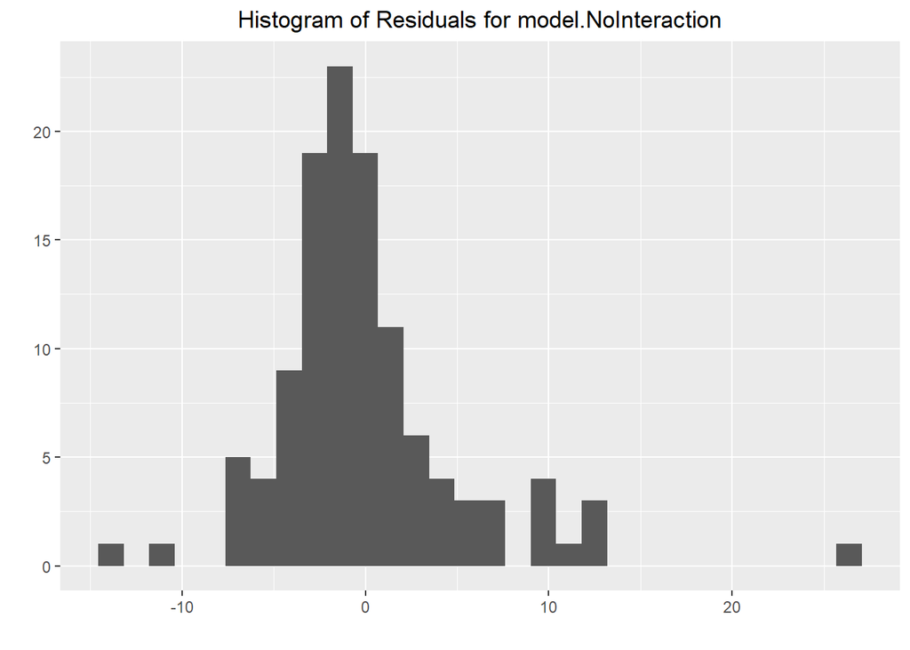

```r
# Data to fit
data_modified_team <- team_data %>%
  select(TeamScore,
         params$dependent_response_team,
         Target,
         SessionOrder,
         Team)

# Plot location
setwd(figure_directory)

# Generate models with variable response
data_focus_team <- data_modified_team
model.NoInteraction <- model_data_Target_Session(df = data_focus_team, dependent =  params$dependent_response_team, model.type =  "NoInteraction", is.team = TRUE, is.robust = FALSE)

# Histogram of Residuals - model.NoInteraction
ggplot(model.NoInteraction, aes(x = .resid)) +
  geom_histogram(bins = 30) +
  labs(title = paste("Histogram of Residuals for model.NoInteraction"), x = "", y = "") +
  theme(plot.title = element_text(hjust = 0.5)) +
  ggsave(filename = paste("Histogram_Residuals_", params$dependent_response_name_NoSpace, "_NoInteraction_Team.png", sep = ""))
```

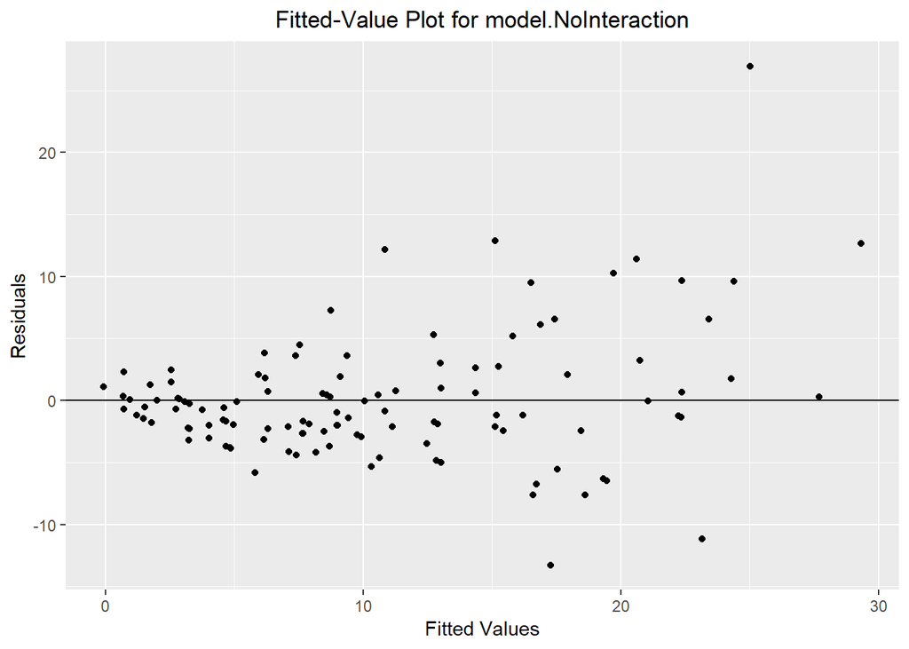

```r
# Fitted values - model.NoInteraction
ggplot(model.NoInteraction, aes(x = .fitted, y = .resid)) +
  geom_point() +
  geom_hline(yintercept = 0)+
  labs(title = paste("Fitted-Value Plot for model.NoInteraction"), x = "Fitted Values", y = "Residuals") +
  theme(plot.title = element_text(hjust = 0.5)) +
  ggsave(filename = paste("FitteValue_Residuals_", params$dependent_response_name_NoSpace, "_NoInteraction_Team.png", sep = ""))
```

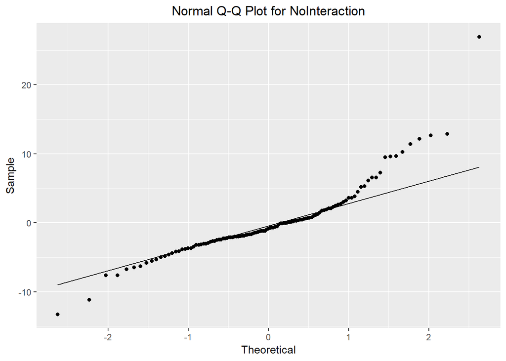

```r
# QQ plots - model.NoInteraction
ggplot(model.NoInteraction, aes(sample = .resid)) +
  stat_qq() +
  stat_qq_line()+
  labs(title = "Normal Q-Q Plot for NoInteraction", x = "Theoretical", y = "Sample") +
   theme(plot.title = element_text(hjust = 0.5)) +
  ggsave(filename = paste("QQ_Residuals_", params$dependent_response_name_NoSpace, "_NoInteraction_Team.png", sep = ""))
```

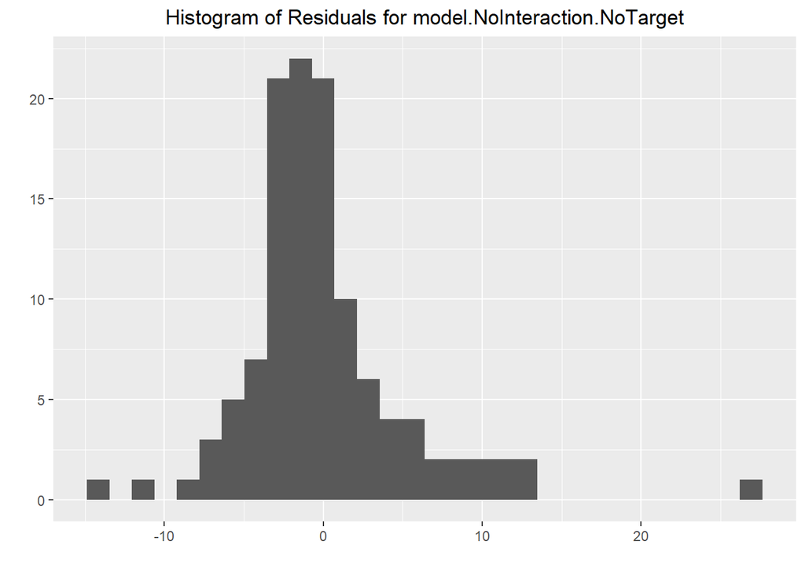

```r
# Data to fit
data_modified_team <- team_data %>%
  select(TeamScore,
         params$dependent_response_team,
         Target,
         SessionOrder,
         Team)

# Plot location
setwd(figure_directory)

# Generate models with variable response

data_focus_team <- data_modified_team
model.NoInteraction.NoTarget <- model_data_Target_Session(df = data_focus_team, dependent =  params$dependent_response_team, model.type =  "NoInteraction_NoTarget", is.team = TRUE, is.robust = FALSE)

# Histogram of Residuals - model.NoInteraction.NoTarget
ggplot(model.NoInteraction.NoTarget, aes(x = .resid)) +
  geom_histogram(bins = 30) +
  labs(title = paste("Histogram of Residuals for model.NoInteraction.NoTarget"), x = "", y = "") +
  theme(plot.title = element_text(hjust = 0.5)) +
  ggsave(filename = paste("Histogram_Residuals_", params$dependent_response_name_NoSpace, "_NoInteraction.NoTarget_Team.png", sep = ""))
```

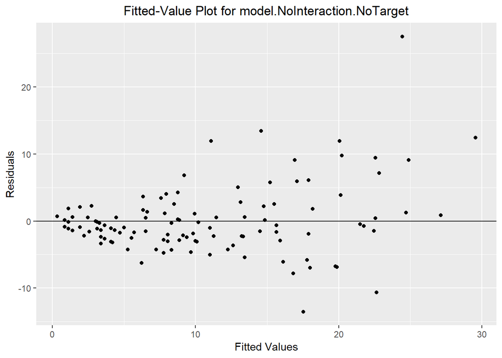

```r
# Fitted values - model.NoInteraction.NoTarget
ggplot(model.NoInteraction.NoTarget, aes(x = .fitted, y = .resid)) +
  geom_point() +
  geom_hline(yintercept = 0)+
  labs(title = paste("Fitted-Value Plot for model.NoInteraction.NoTarget"), x = "Fitted Values", y = "Residuals") +
  theme(plot.title = element_text(hjust = 0.5)) +
  ggsave(filename = paste("FitteValue_Residuals_", params$dependent_response_name_NoSpace, "_NoInteraction.NoTarget_Team.png", sep = ""))
```

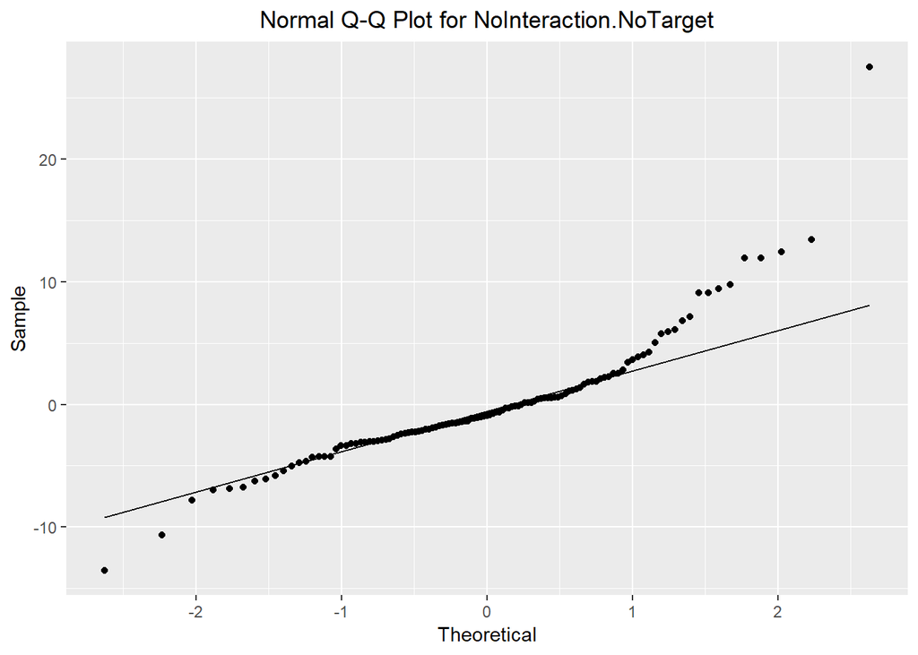

```r
# QQ plots - model.NoInteraction.NoTarget
ggplot(model.NoInteraction.NoTarget, aes(sample = .resid)) +
  stat_qq() +
  stat_qq_line()+
  labs(title = "Normal Q-Q Plot for NoInteraction.NoTarget", x = "Theoretical", y = "Sample") +
   theme(plot.title = element_text(hjust = 0.5)) +
  ggsave(filename = paste("QQ_Residuals_", params$dependent_response_name_NoSpace, "_NoInteraction.NoTarget_Team.png", sep = ""))
```

##### Q: Does the violation influence the linear model estimation?

I will use the robust estimation for linear mixed models found in the robustlmm package by Koller (2016). I will then compare the robust model to the non-robust model. If the estimated values are noticeably different, then data will need to be transformed.

###### Model.NoInteraction

```r
# Data to fit
data_modified_team <- team_data %>%
  select(TeamScore,
         params$dependent_response_team,
         Target,
         SessionOrder,
         Team)

data_focus_team <- data_modified_team

# Generate robust and non-robust models - NoInteraction
model.NoInteraction <- model_data_Target_Session(df = data_focus_team, dependent =  params$dependent_response_team, model.type =  "NoInteraction", is.team = TRUE, is.robust = FALSE)
rmodel.NoInteraction <- model_data_Target_Session(df = data_focus_team, dependent =  params$dependent_response_team, model.type =  "NoInteraction", is.team = TRUE, is.robust = TRUE)

comparision_results <- compare(model.NoInteraction, rmodel.NoInteraction, show.rho.functions = FALSE)

comparision_results %>%
  kable(caption = "model.NoInteraction") %>%
  kable_styling()
```

model.NoInteraction

|  | model.NoInteraction | rmodel.NoInteraction |
| --- | --- | --- |
| Coef |  |  |
| (Intercept) | 14.218 (1.70) | 12.775 (1.468) |
| TargetInd_Team | 0.793 (1.40) | 0.162 (0.936) |
| TargetTeam | -0.232 (1.39) | -0.102 (0.936) |
| SessionOrder3 | -4.687 (1.39) | -3.708 (0.936) |
| SessionOrder4 | -6.964 (1.40) | -6.064 (0.936) |
| VarComp |  |  |
| (Intercept) \| Team | 7.17 | 7.33 |
| sigma | 6.15 | 4.03 |
| REML | 804 |  |

The robust model.NoInteraction model is noticeably different from the non-robust model.NoInteraction. This suggests that the data should be transformed to satisfy the residual assumptions.

###### Model.NoInteraction.NoTarget

```r
# Data to fit
data_modified_team <- team_data %>%
  select(TeamScore,
         params$dependent_response_team,
         Target,
         SessionOrder,
         Team)

data_focus_team <- data_modified_team

# Generate robust and non-robust models - NoInteraction.NoTarget
model.NoInteraction.NoTarget <- model_data_Target_Session(df = data_focus_team, dependent =  params$dependent_response_team, model.type =  "NoInteraction_NoTarget", is.team = TRUE, is.robust = FALSE)
rmodel.NoInteraction.NoTarget <- model_data_Target_Session(df = data_focus_team, dependent =  params$dependent_response_team, model.type =  "NoInteraction_NoTarget", is.team = TRUE, is.robust = TRUE)

comparision_results <- compare(model.NoInteraction.NoTarget, rmodel.NoInteraction.NoTarget, show.rho.functions = FALSE)

comparision_results %>%
  kable(caption = "model.NoInteraction.NoTarget") %>%
  kable_styling()
```

model.NoInteraction.NoTarget

|  | model.NoInteraction.NoTarget | rmodel.NoInteraction.NoTarget |
| --- | --- | --- |
| Coef |  |  |
| (Intercept) | 14.38 (1.51) | 12.78 (1.369) |
| SessionOrder3 | -4.67 (1.38) | -3.70 (0.921) |
| SessionOrder4 | -6.92 (1.38) | -6.04 (0.921) |
| VarComp |  |  |
| (Intercept) \| Team | 7.18 | 7.33 |
| sigma | 6.1 | 3.97 |
| REML | 809 |  |

The robust model.NoInteraction.NoTarget model is noticeably different from the non-robust model.NoInteraction.NoTarget This suggests that the data should be transformed to satisfy the residual assumptions.

##### Q: Does data transformation satisfy the assumptions of the residuals?

I will use the square root transformation method from Tukey’s ladder (Tukey, 1977).

###### Model.NoInteraction

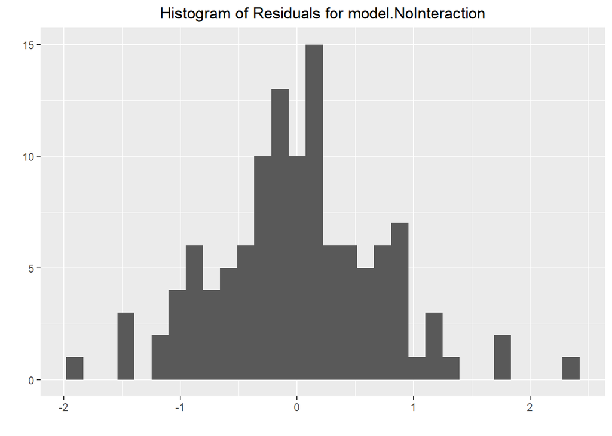

```r
# Data to fit
data_modified_team <- team_data %>%
  select(TeamScore,
         params$dependent_response_team,
         Target,
         SessionOrder,
         Team) %>%
  mutate(sqrt.value = sqrt(.data[[params$dependent_response_team]]))

#response_variable <- "sqrt.value"
data_focus_team <- data_modified_team

#Plot location
setwd(figure_directory)

# Generate non-robust models - NoInteraction
model.NoInteraction <- model_data_Target_Session(df = data_focus_team, dependent =  "sqrt.value", model.type =  "NoInteraction", is.team = TRUE, is.robust = FALSE)

# Histogram of Residuals - model.NoInteraction
ggplot(model.NoInteraction, aes(x = .resid)) +
  geom_histogram(bins = 30) +
  labs(title = paste("Histogram of Residuals for model.NoInteraction"), x = "", y = "") +
  theme(plot.title = element_text(hjust = 0.5)) +
  ggsave(paste("Histogram_Residuals_", params$dependent_response_name_NoSpace, "_sqrt_NoInteraction_Team.png", sep = ""))
```

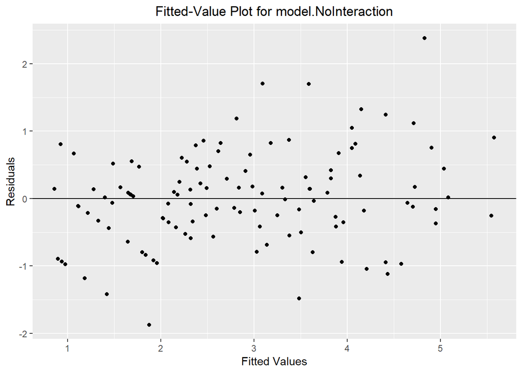

```r
# Fitted values - model.NoInteraction
ggplot(model.NoInteraction, aes(x = .fitted, y = .resid)) +
  geom_point() +
  geom_hline(yintercept = 0)+
  labs(title = paste("Fitted-Value Plot for model.NoInteraction"), x = "Fitted Values", y = "Residuals") +
  theme(plot.title = element_text(hjust = 0.5)) +
  ggsave(paste("FitteValue_Residuals_", params$dependent_response_name_NoSpace, "_sqrt_NoInteraction_Team.png", sep = ""))
```

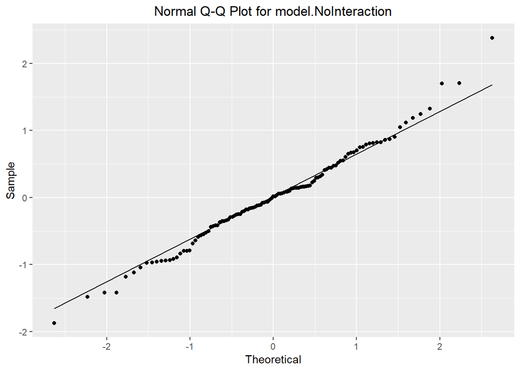

```r
# QQ plots - model.NoInteraction
ggplot(model.NoInteraction, aes(sample = .resid)) +
  stat_qq() +
  stat_qq_line()+
  labs(title = "Normal Q-Q Plot for model.NoInteraction", x = "Theoretical", y = "Sample") +
   theme(plot.title = element_text(hjust = 0.5)) +
  ggsave(paste("QQ_Residuals_", params$dependent_response_name_NoSpace, "_sqrt_NoInteraction_Team.png", sep = ""))
```

The diagnostic plots suggest the transformation has resolved the assumption violations for the model.NoInteraction.

###### Model.NoInteraction.NoTarget

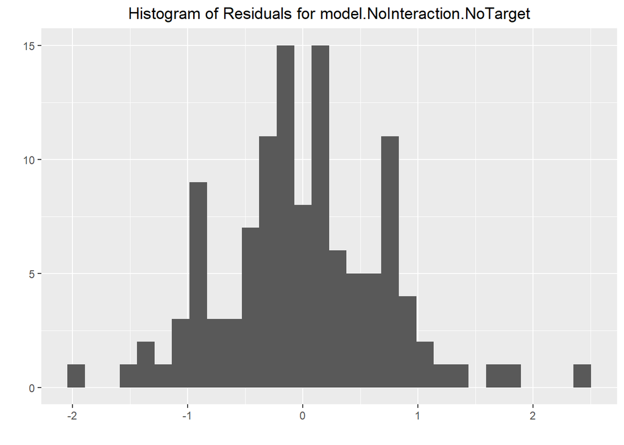

```r
# Data to fit
data_modified_team <- team_data %>%
  select(TeamScore,
         params$dependent_response_team,
         Target,
         SessionOrder,
         Team) %>%
  mutate(sqrt.value = sqrt(.data[[params$dependent_response_team]]))

response_variable <- "sqrt.value"
data_focus_team <- data_modified_team

model.NoInteraction.NoTarget <- model_data_Target_Session(df = data_focus_team, dependent =  "sqrt.value", model.type =  "NoInteraction_NoTarget", is.team = TRUE, is.robust = FALSE)

# Plot location
setwd(figure_directory)

# Histogram of Residuals - model.NoInteraction.NoTarget
ggplot(model.NoInteraction.NoTarget, aes(x = .resid)) +
  geom_histogram(bins = 30) +
  labs(title = paste("Histogram of Residuals for model.NoInteraction.NoTarget"), x = "", y = "") +
  theme(plot.title = element_text(hjust = 0.5)) +
  ggsave(paste("Histogram_Residuals_", params$dependent_response_name_NoSpace, "_sqrt_NoInteraction.NoTarget_Team.png", sep = ""))
```

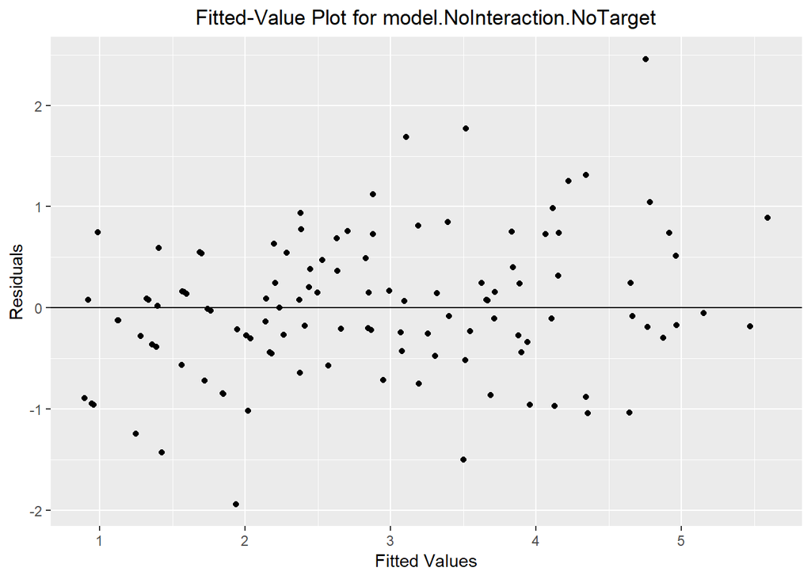

```r
# Fitted values - model.NoInteraction.NoTarget
ggplot(model.NoInteraction.NoTarget, aes(x = .fitted, y = .resid)) +
  geom_point() +
  geom_hline(yintercept = 0)+
  labs(title = paste("Fitted-Value Plot for model.NoInteraction.NoTarget"), x = "Fitted Values", y = "Residuals") +
  theme(plot.title = element_text(hjust = 0.5)) +
  ggsave(paste("FittedValue_Residuals_", params$dependent_response_name_NoSpace, "_sqrt_NoInteraction.NoTarget_Team.png", sep = ""))
```

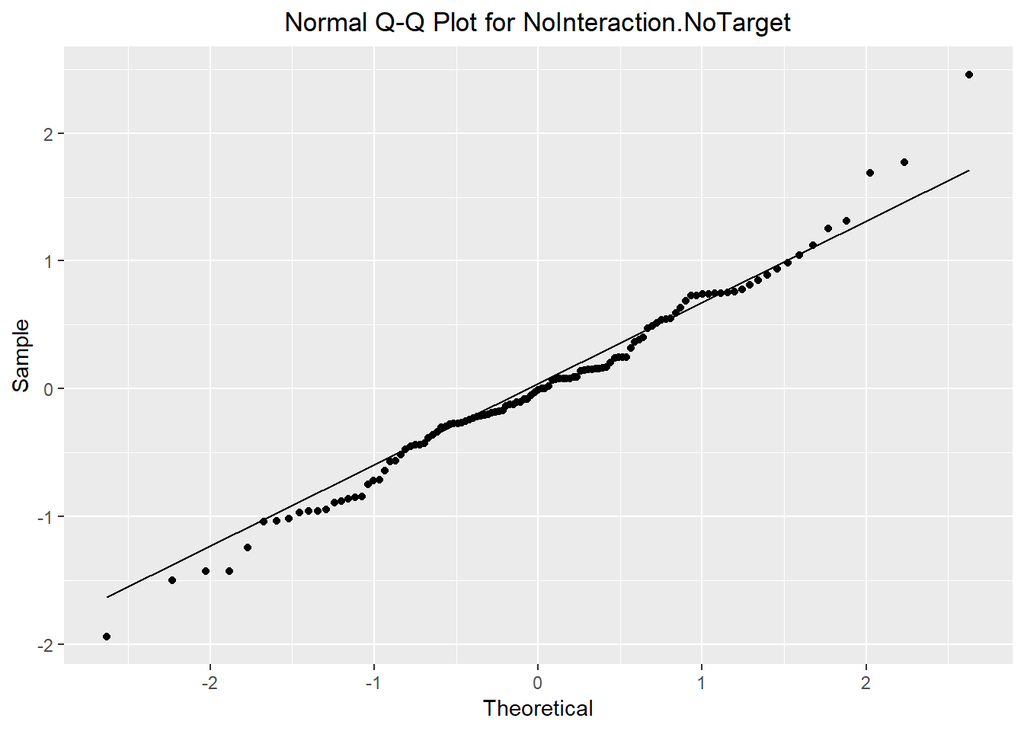

```r
# QQ plots - model.NoInteraction.NoTarget
ggplot(model.NoInteraction.NoTarget, aes(sample = .resid)) +
  stat_qq() +
  stat_qq_line()+
  labs(title = "Normal Q-Q Plot for NoInteraction.NoTarget", x = "Theoretical", y = "Sample") +
   theme(plot.title = element_text(hjust = 0.5)) +
  ggsave(paste("QQ_Residuals_", params$dependent_response_name_NoSpace, "_sqrt_NoInteraction.NoTarget_Team.png", sep = ""))
```

##### Q: Are there any effects that are significant?

I want to determine if Target has a significant effect. I will examine the model itself, and then I will calculate the estimated marginal means to compare all three levels.

###### Model.NoInteraction

```r
# Data to fit
data_modified_team <- team_data %>%
  select(TeamScore,
         params$dependent_response_team,
         Target,
         SessionOrder,
         Team) %>%
  mutate(sqrt.value = sqrt(.data[[params$dependent_response_team]]))

#response_variable <- "sqrt.value"
data_focus_team <- data_modified_team

# Generate robust and non-robust models - NoInteraction
model.NoInteraction <- model_data_Target_Session(df = data_focus_team, dependent =  "sqrt.value", model.type =  "NoInteraction", is.team = TRUE, is.robust = FALSE)

summary(model.NoInteraction)
```

```
## Linear mixed model fit by REML. t-tests use Satterthwaite's method [
## lmerModLmerTest]
## Formula:
## as.formula(paste(dependent, "~ Target + SessionOrder + (1|Team)"))
##    Data: df
##
## REML criterion at convergence: 371.6
##
## Scaled residuals:
##     Min      1Q  Median      3Q     Max
## -2.1962 -0.4879  0.0164  0.5167  2.7950
##
## Random effects:
##  Groups   Name        Variance Std.Dev.
##  Team     (Intercept) 1.3790   1.1743
##  Residual             0.7274   0.8529
## Number of obs: 117, groups:  Team, 39
##
## Fixed effects:
##                Estimate Std. Error       df t value Pr(>|t|)
## (Intercept)     3.54132    0.25600 80.66114  13.833  < 2e-16 ***
## TargetInd_Team  0.08940    0.19340 74.00001   0.462    0.645
## TargetTeam     -0.05064    0.19321 74.00001  -0.262    0.794
## SessionOrder3  -0.81195    0.19321 74.00001  -4.202 7.29e-05 ***
## SessionOrder4  -1.25489    0.19340 74.00001  -6.489 8.69e-09 ***
## ---
## Signif. codes:  0 '***' 0.001 '**' 0.01 '*' 0.05 '.' 0.1 ' ' 1
##
## Correlation of Fixed Effects:
##             (Intr) TrgI_T TrgtTm SssnO3
## TargtInd_Tm -0.358
## TargetTeam  -0.368  0.500
## SessinOrdr3 -0.368 -0.026 -0.013
## SessinOrdr4 -0.358 -0.051 -0.026  0.500
```

The estimations are in reference to the Ind level for the Target variable and session 2 for the session order variable. The results suggest that session 3 and 4 have a significant effect. The results also indicate that the impact of the Team and Ind_Team levels do not have an effect that is greater than zero, in reference to the Ind level.

```r
# Data to fit
data_modified_team <- team_data %>%
  select(TeamScore,
         params$dependent_response_team,
         Target,
         SessionOrder,
         Team) %>%
  mutate(sqrt.value = sqrt(.data[[params$dependent_response_team]]))

#response_variable <- "sqrt.value"
data_focus_team <- data_modified_team

# Generate robust and non-robust models - NoInteraction
model.NoInteraction <- model_data_Target_Session(df = data_focus_team, dependent =  "sqrt.value", model.type =  "NoInteraction", is.team = TRUE, is.robust = FALSE)

emmeans(model.NoInteraction, list(pairwise ~ Target), adjust = "tukey")
```

```
## $`emmeans of Target`
##  Target   emmean    SE   df lower.CL upper.CL
##  Ind        2.85 0.232 61.4     2.39     3.32
##  Ind_Team   2.94 0.232 61.4     2.48     3.41
##  Team       2.80 0.232 61.3     2.34     3.27
##
## Results are averaged over the levels of: SessionOrder
## Degrees-of-freedom method: satterthwaite
## Confidence level used: 0.95
##
## $`pairwise differences of Target`
##  contrast        estimate    SE df t.ratio p.value
##  Ind - Ind_Team   -0.0894 0.193 74 -0.462  0.8891
##  Ind - Team        0.0506 0.193 74  0.262  0.9629
##  Ind_Team - Team   0.1400 0.193 74  0.725  0.7496
##
## Results are averaged over the levels of: SessionOrder
## P value adjustment: tukey method for comparing a family of 3 estimates
```

The estimated marginal means show no significant difference among the Target variables.

```r
# Data to fit
data_modified_team <- team_data %>%
  select(TeamScore,
         params$dependent_response_team,
         Target,
         SessionOrder,
         Team) %>%
  mutate(sqrt.value = sqrt(.data[[params$dependent_response_team]]))

#response_variable <- "sqrt.value"
data_focus_team <- data_modified_team

# Generate robust and non-robust models - NoInteraction
model.NoInteraction <- model_data_Target_Session(df = data_focus_team, dependent =  "sqrt.value", model.type =  "NoInteraction", is.team = TRUE, is.robust = FALSE)

emmeans(model.NoInteraction, list(pairwise ~ SessionOrder), adjust = "tukey")
```

```
## $`emmeans of SessionOrder`
##  SessionOrder emmean    SE   df lower.CL upper.CL
##  2              3.55 0.232 61.4     3.09     4.02
##  3              2.74 0.232 61.3     2.28     3.21
##  4              2.30 0.232 61.4     1.83     2.76
##
## Results are averaged over the levels of: Target
## Degrees-of-freedom method: satterthwaite
## Confidence level used: 0.95
##
## $`pairwise differences of SessionOrder`
##  contrast estimate    SE df t.ratio p.value
##  2 - 3       0.812 0.193 74 4.202   0.0002
##  2 - 4       1.255 0.193 74 6.489   <.0001
##  3 - 4       0.443 0.193 74 2.293   0.0631
##
## Results are averaged over the levels of: Target
## P value adjustment: tukey method for comparing a family of 3 estimates
```

The resuls show a signifcant difference between session 2 and 3, and between sessions 2 and 4. It is important to note that the difference between session 3 and 4 is approaching significance (p = 0.0631). This means teams were committing less errors over time.

###### Model.NoInteraction.NoTarget

```r
# Data to fit
data_modified_team <- team_data %>%
  select(TeamScore,
         params$dependent_response_team,
         Target,
         SessionOrder,
         Team) %>%
  mutate(sqrt.value = sqrt(.data[[params$dependent_response_team]]))

#response_variable <- "sqrt.value"
data_focus_team <- data_modified_team

# Generate robust and non-robust models - NoInteraction_NoTarget
model.NoInteraction.NoTarget <- model_data_Target_Session(df = data_focus_team, dependent =  "sqrt.value", model.type =  "NoInteraction_NoTarget", is.team = TRUE, is.robust = FALSE)

summary(model.NoInteraction.NoTarget)
```

```
## Linear mixed model fit by REML. t-tests use Satterthwaite's method [
## lmerModLmerTest]
## Formula: as.formula(paste(dependent, "~ SessionOrder + (1|Team)"))
##    Data: df
##
## REML criterion at convergence: 369
##
## Scaled residuals:
##     Min      1Q  Median      3Q     Max
## -2.2941 -0.4572 -0.0111  0.5575  2.9107
##
## Random effects:
##  Groups   Name        Variance Std.Dev.
##  Team     (Intercept) 1.3837   1.1763
##  Residual             0.7134   0.8447
## Number of obs: 117, groups:  Team, 39
##
## Fixed effects:
##               Estimate Std. Error      df t value Pr(>|t|)
## (Intercept)     3.5520     0.2319 60.9410  15.318  < 2e-16 ***
## SessionOrder3  -0.8097     0.1913 76.0000  -4.233 6.39e-05 ***
## SessionOrder4  -1.2503     0.1913 76.0000  -6.537 6.46e-09 ***
## ---
## Signif. codes:  0 '***' 0.001 '**' 0.01 '*' 0.05 '.' 0.1 ' ' 1
##
## Correlation of Fixed Effects:
##             (Intr) SssnO3
## SessinOrdr3 -0.412
## SessinOrdr4 -0.412  0.500
```

The results show that the effect from session 3 and 4 is signifcantly greater than 0 in reference to session 2.

```r
# Data to fit
data_modified_team <- team_data %>%
  select(TeamScore,
         params$dependent_response_team,
         Target,
         SessionOrder,
         Team) %>%
  mutate(sqrt.value = sqrt(.data[[params$dependent_response_team]]))

#response_variable <- "sqrt.value"
data_focus_team <- data_modified_team

# Generate robust and non-robust models - NoInteraction_NoTarget
model.NoInteraction.NoTarget <- model_data_Target_Session(df = data_focus_team, dependent =  "sqrt.value", model.type =  "NoInteraction_NoTarget", is.team = TRUE, is.robust = FALSE)

emmeans(model.NoInteraction.NoTarget, list(pairwise ~ SessionOrder), adjust = "tukey")
```

```
## $`emmeans of SessionOrder`
##  SessionOrder emmean    SE   df lower.CL upper.CL
##  2              3.55 0.232 60.9     3.09     4.02
##  3              2.74 0.232 60.9     2.28     3.21
##  4              2.30 0.232 60.9     1.84     2.77
##
## Degrees-of-freedom method: satterthwaite
## Confidence level used: 0.95
##
## $`pairwise differences of SessionOrder`
##  contrast estimate    SE df t.ratio p.value
##  2 - 3       0.810 0.191 76 4.233   0.0002
##  2 - 4       1.250 0.191 76 6.537   <.0001
##  3 - 4       0.441 0.191 76 2.304   0.0613
##
## P value adjustment: tukey method for comparing a family of 3 estimates
```

The resuls show a signifcant difference between session 2 and 3, and between sessions 2 and 4. It is important to note that the difference between session 3 and 4 is approaching significance (p = 0.0613). This means teams were committing less errors over time.

##### Summary / Reflection

Overall, there were no surprising statistical findings that was unepected or intersting. This lack of statistical significance was expected based on the visual representation of the data distribution.

#### Individual

We learned that **model.NoInteraction** and **model.NoInteraction.NoTarget** best describe the individual level data(see previous analysis).

##### model.NoInteraction

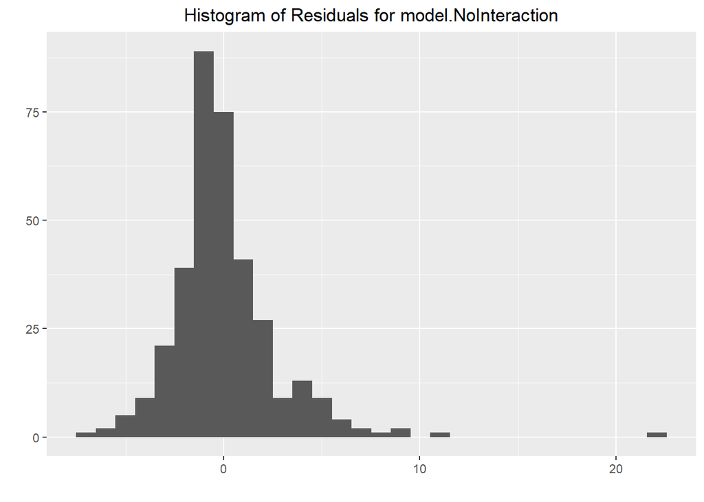

```r
# Data to model
data_modified_ind <- ind_data %>%
  select(params$dependent_response_ind,
         Target,
         SessionOrder,
         Team,
         Player_ID)

# Plot location
setwd(figure_directory)

# Generate models with variable response

data_focus_ind <- data_modified_ind
model.NoInteraction <- model_data_Target_Session(df = data_focus_ind, dependent =  params$dependent_response_ind, model.type =  "NoInteraction", is.team = FALSE, is.robust = FALSE)

# Histogram of Residuals - model.NoInteraction
ggplot(model.NoInteraction, aes(x = .resid)) +
  geom_histogram(bins = 30) +
  labs(title = paste("Histogram of Residuals for model.NoInteraction"), x = "", y = "") +
  theme(plot.title = element_text(hjust = 0.5)) +
  ggsave(paste("Histogram_Residuals_", params$dependent_response_name_NoSpace, "_NoInteraction_Ind.png", sep =""))
```

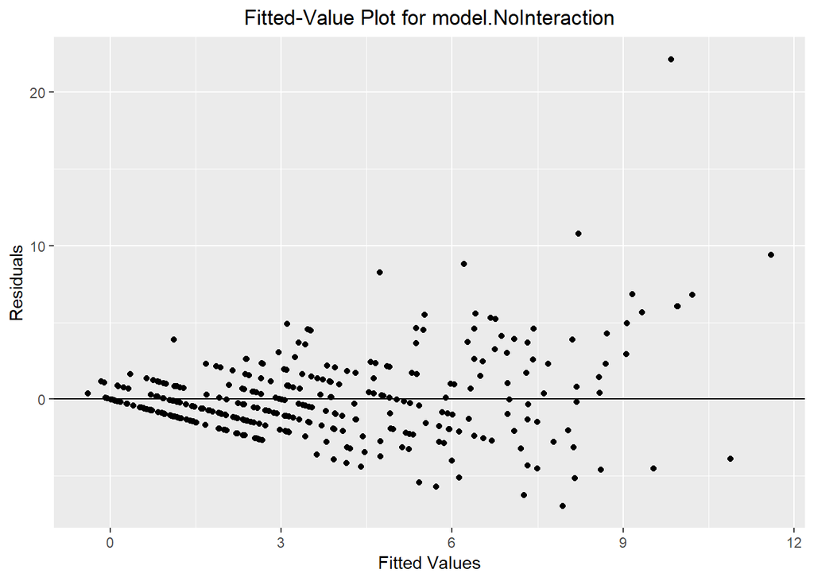

```r
# Fitted values - model.NoInteraction
ggplot(model.NoInteraction, aes(x = .fitted, y = .resid)) +
  geom_point() +
  geom_hline(yintercept = 0)+
  labs(title = paste("Fitted-Value Plot for model.NoInteraction"), x = "Fitted Values", y = "Residuals") +
  theme(plot.title = element_text(hjust = 0.5)) +
  ggsave(paste("FittedValue_Residuals_", params$dependent_response_name_NoSpace, "_NoInteraction_Ind.png", sep =""))
```

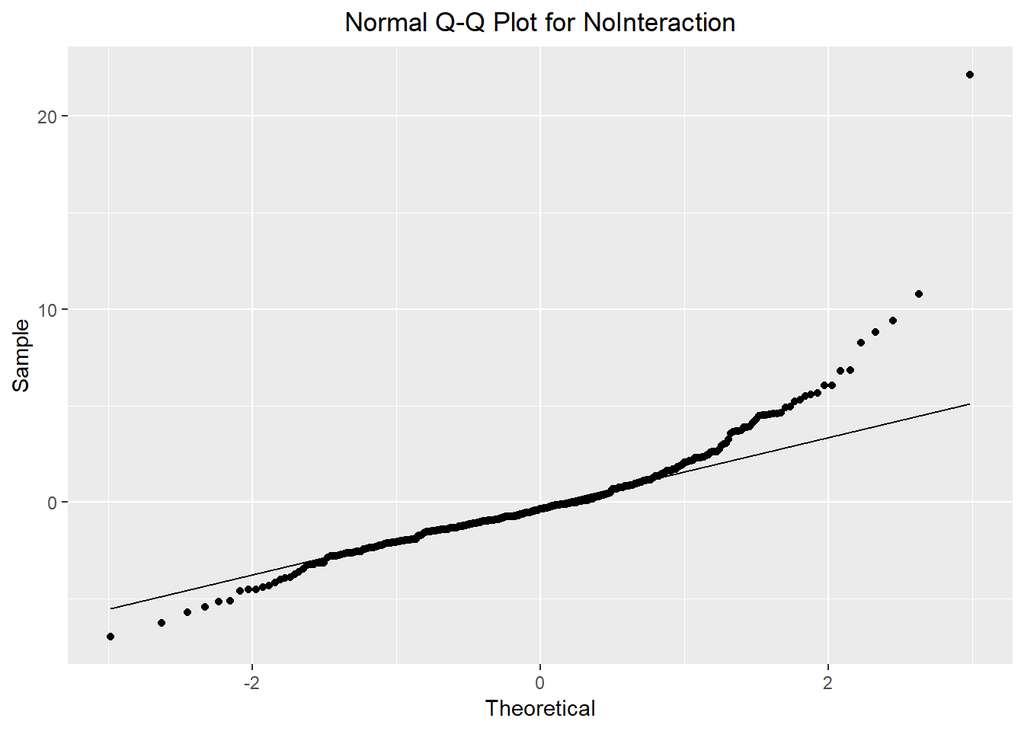

```r
# QQ plots - model.NoInteraction
ggplot(model.NoInteraction, aes(sample = .resid)) +
  stat_qq() +
  stat_qq_line()+
  labs(title = "Normal Q-Q Plot for NoInteraction", x = "Theoretical", y = "Sample") +
   theme(plot.title = element_text(hjust = 0.5)) +
  ggsave(paste("QQ_Residuals_", params$dependent_response_name_NoSpace, "_NoInteraction_Ind.png", sep =""))
```

model.NoInteraction: Visually, it looks like the model violates assumption 2 and 3 in the fitted-value plot and the QQ plot, respectively. I will need to compare this model to a robust model to examine the influence of the apparent violation. If there is a noticeable difference, I will need to transform the data.

##### model.NoInteraction.NoTarget

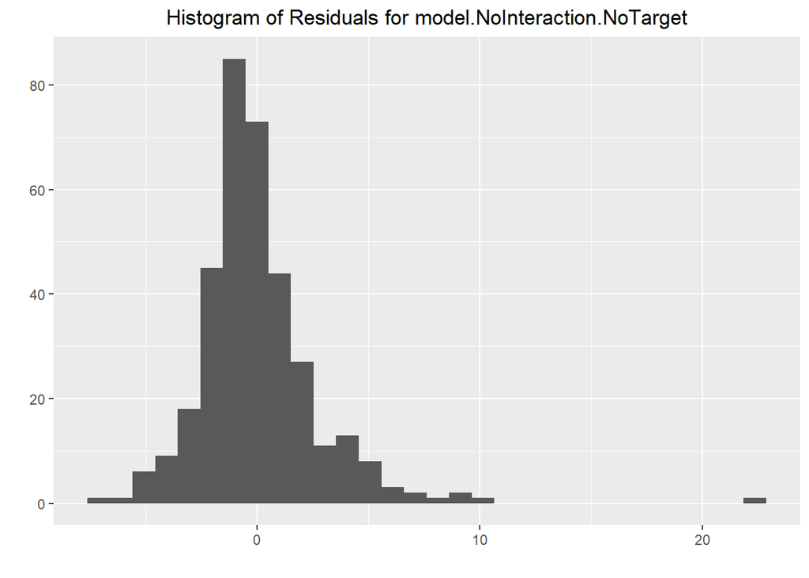

```r
# Data to model
data_modified_ind <- ind_data %>%
  select(params$dependent_response_ind,
         Target,
         SessionOrder,
         Team,
         Player_ID)

# Plot location
setwd(figure_directory)

# Generate models with variable response

data_focus_ind <- data_modified_ind
model.NoInteraction.NoTarget <- model_data_Target_Session(df = data_focus_ind, dependent =  params$dependent_response_ind, model.type =  "NoInteraction_NoTarget", is.team = FALSE, is.robust = FALSE)

# Histogram of Residuals - model.NoInteraction.NoTarget
ggplot(model.NoInteraction.NoTarget, aes(x = .resid)) +
  geom_histogram(bins = 30) +
  labs(title = paste("Histogram of Residuals for model.NoInteraction.NoTarget"), x = "", y = "") +
  theme(plot.title = element_text(hjust = 0.5)) +
  ggsave(paste("Histogram_Residuals_", params$dependent_response_name_NoSpace, "_NoInteraction_Ind.png", sep =""))
```

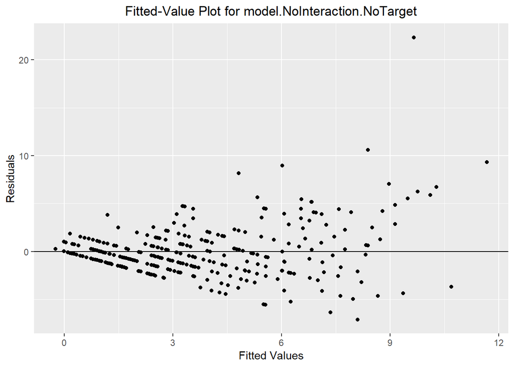

```r
# Fitted values - model.NoInteraction.NoTarget
ggplot(model.NoInteraction.NoTarget, aes(x = .fitted, y = .resid)) +
  geom_point() +
  geom_hline(yintercept = 0)+
  labs(title = paste("Fitted-Value Plot for model.NoInteraction.NoTarget"), x = "Fitted Values", y = "Residuals") +
  theme(plot.title = element_text(hjust = 0.5)) +
  ggsave(paste("FittedValue_Residuals_", params$dependent_response_name_NoSpace, "_NoInteraction_Ind.png", sep =""))
```

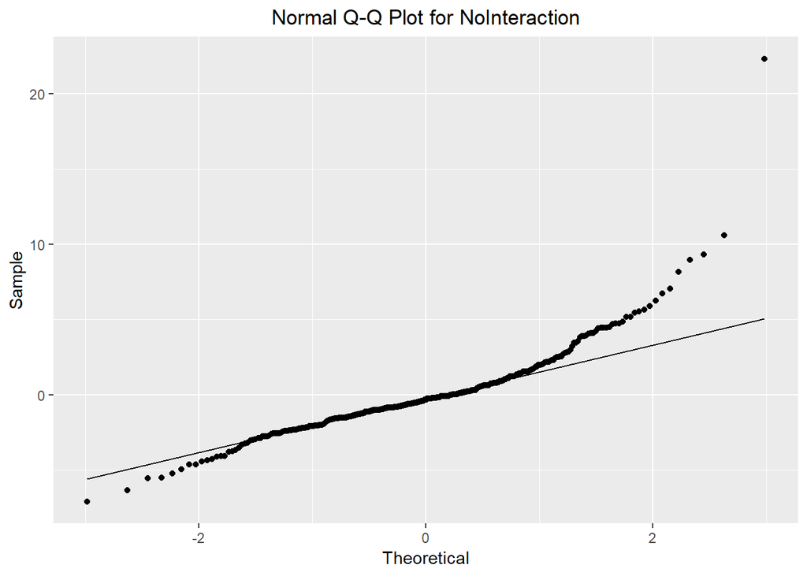

```r
# QQ plots - model.NoInteraction.NoTarget
ggplot(model.NoInteraction.NoTarget, aes(sample = .resid)) +
  stat_qq() +
  stat_qq_line()+
  labs(title = "Normal Q-Q Plot for NoInteraction", x = "Theoretical", y = "Sample") +
   theme(plot.title = element_text(hjust = 0.5)) +
  ggsave(paste("QQ_Residuals_", params$dependent_response_name_NoSpace, "_NoInteraction_Ind.png", sep =""))
```

Visually, it looks like the model violates assumption 2 and 3 in the fitted-value plot and the QQ plot, respectively. I will need to compare this model to a robust model to examine the influence of the apparent violation. If there is a noticeable difference, I will need to transform the data.

##### Q: Does the violation influence the model estimation?

I will use the robust estimation for linear mixed models found in the robustlmm package by Koller (2016). I will then compare the robust model to the non-robust model. If the estimated values are noticeably different, then data will need to be transformed.

##### model.NoInteraction

```r
# Data to model
data_modified_ind <- ind_data %>%
  select(params$dependent_response_ind,
         Target,
         SessionOrder,
         Team,
         Player_ID)

# Generate models with variable response
data_focus_ind <- data_modified_ind
model.NoInteraction <- model_data_Target_Session(df = data_focus_ind, dependent =  params$dependent_response_ind, model.type =  "NoInteraction", is.team = FALSE, is.robust = FALSE)
rmodel.NoInteraction <- model_data_Target_Session(df = data_focus_ind, dependent =  params$dependent_response_ind, model.type =  "NoInteraction", is.team = FALSE, is.robust = TRUE)

comparision_results <- compare(model.NoInteraction, rmodel.NoInteraction, show.rho.functions = FALSE)

comparision_results %>%
  kable(caption = "model.NoInteraction") %>%
  kable_styling()
```

model.NoInteraction

|  | model.NoInteraction | rmodel.NoInteraction |
| --- | --- | --- |
| Coef |  |  |
| (Intercept) | 4.7393 (0.529) | 4.10713 (0.477) |
| TargetInd_Team | 0.2643 (0.391) | 0.08318 (0.302) |
| TargetTeam | -0.0772 (0.390) | 0.00092 (0.302) |
| SessionOrder3 | -1.5623 (0.390) | -1.15743 (0.302) |
| SessionOrder4 | -2.3212 (0.391) | -1.94062 (0.302) |
| VarComp |  |  |
| (Intercept) \| Player_ID | 1.25 | 0.00 |
| (Intercept) \| Team | 2.37 | 2.39 |
| sigma | 2.99 | 2.25 |
| REML | 1869 |  |

There is a noticeable difference between the non-robust model and the robust model. This noticeable difference indicates that the data should be transformed to attempt to satisfy the assumptions.

##### model.NoInteraction.NoTarget

```r
# Data to model
data_modified_ind <- ind_data %>%
  select(params$dependent_response_ind,
         Target,
         SessionOrder,
         Team,
         Player_ID)

# Generate models with variable response
data_focus_ind <- data_modified_ind
model.NoInteraction.NoTarget <- model_data_Target_Session(df = data_focus_ind, dependent =  params$dependent_response_ind, model.type =  "NoInteraction_NoTarget", is.team = FALSE, is.robust = FALSE)
rmodel.NoInteraction.NoTarget <- model_data_Target_Session(df = data_focus_ind, dependent =  params$dependent_response_ind, model.type =  "NoInteraction_NoTarget", is.team = FALSE, is.robust = TRUE)

comparision_results <- compare(model.NoInteraction.NoTarget, rmodel.NoInteraction.NoTarget, show.rho.functions = FALSE)

comparision_results %>%
  kable(caption = "model.NoInteraction.NoTarget") %>%
  kable_styling()
```

model.NoInteraction.NoTarget

|  | model.NoInteraction.NoTarget | rmodel.NoInteraction.NoTarget |
| --- | --- | --- |
| Coef |  |  |
| (Intercept) | 4.79 (0.483) | 4.13 (0.445) |
| SessionOrder3 | -1.56 (0.389) | -1.15 (0.300) |
| SessionOrder4 | -2.31 (0.389) | -1.93 (0.300) |
| VarComp |  |  |
| (Intercept) \| Player_ID | 1.25 | 0.00 |
| (Intercept) \| Team | 2.37 | 2.38 |
| sigma | 2.98 | 2.24 |
| REML | 1870 |  |

There is a noticeable difference between the non-robust model and the robust model. This noticeable difference indicates that the data should be transformed to attempt to satisfy the assumptions.

##### Q: Does data transformation satisfy the assumptions of the residuals?

I will use the square root transformation method from Tukey’s ladder (Tukey, 1977).

###### model.NoInteraction

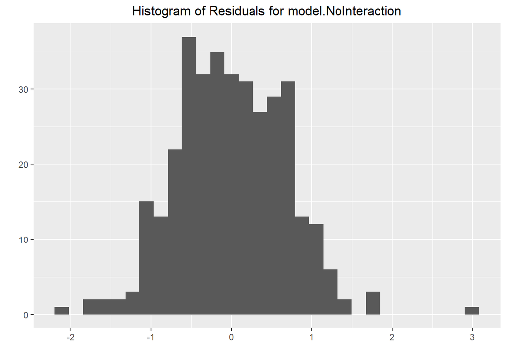

```r
# Data to model
data_modified_ind <- ind_data %>%
  select(params$dependent_response_ind,
         Target,
         SessionOrder,
         Team,
         Player_ID) %>%
  mutate(sqrt.value = sqrt(ifelse(.data[[params$dependent_response_ind]] < 0, 0, .data[[params$dependent_response_ind]]))) # Some of the time remaining vaules are negative when the should be zero. I want to make sure those values are zero

# Plot location
setwd(figure_directory)

#response_variable <- "sqrt.value"
data_focus_ind <- data_modified_ind

# Generate models with variable response
model.NoInteraction <- model_data_Target_Session(df = data_focus_ind, dependent =  "sqrt.value", model.type =  "NoInteraction", is.team = FALSE, is.robust = FALSE)

# Histogram of Residuals - model.NoInteraction
ggplot(model.NoInteraction, aes(x = .resid)) +
  geom_histogram(bins = 30) +
  labs(title = paste("Histogram of Residuals for model.NoInteraction"), x = "", y = "") +
  theme(plot.title = element_text(hjust = 0.5)) +
  ggsave(paste("Histogram_Residuals_", params$dependent_response_name_NoSpace, "_sqrt_NoInteraction_Ind.png", sep =""))
```

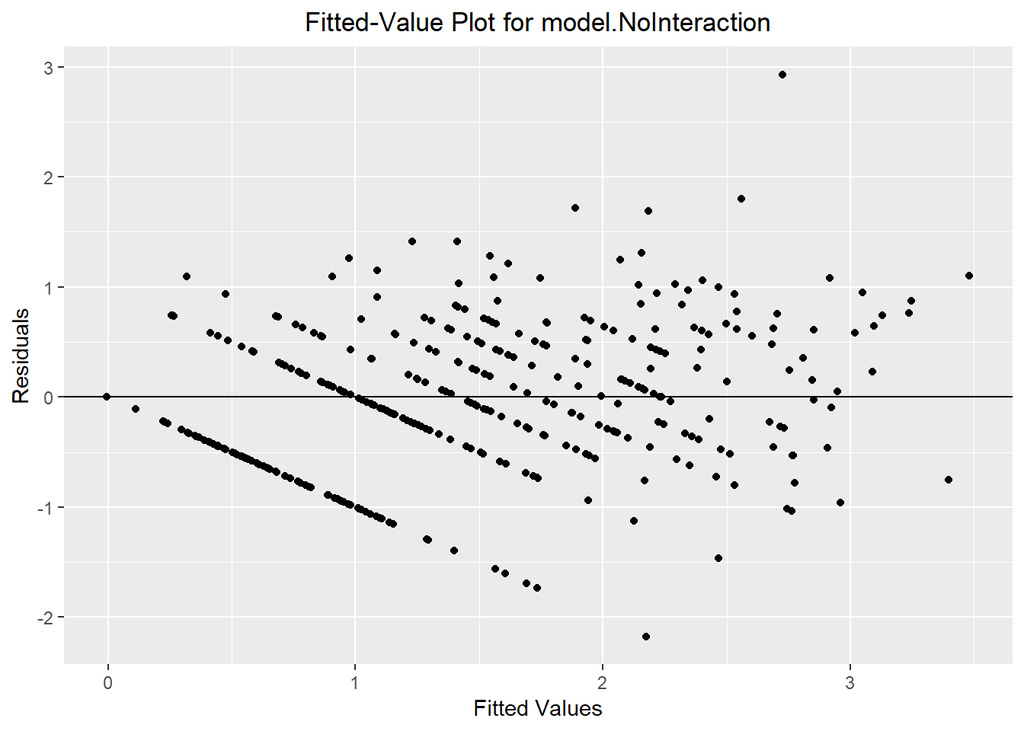

```r
# Fitted values - model.NoInteraction
ggplot(model.NoInteraction, aes(x = .fitted, y = .resid)) +
  geom_point() +
  geom_hline(yintercept = 0)+
  labs(title = paste("Fitted-Value Plot for model.NoInteraction"), x = "Fitted Values", y = "Residuals") +
  theme(plot.title = element_text(hjust = 0.5)) +
  ggsave(paste("FittedValue_Residuals_", params$dependent_response_name_NoSpace, "_sqrt_NoInteraction_Ind.png", sep =""))
```

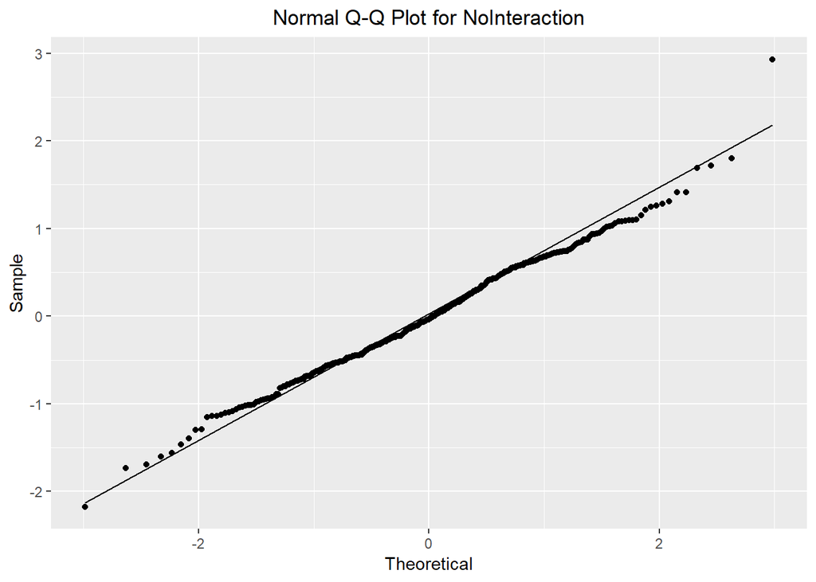

```r
# QQ plots - model.NoInteraction
ggplot(model.NoInteraction, aes(sample = .resid)) +
  stat_qq() +
  stat_qq_line()+
  labs(title = "Normal Q-Q Plot for NoInteraction", x = "Theoretical", y = "Sample") +
  theme(plot.title = element_text(hjust = 0.5)) +
  ggsave(paste("QQ_Residuals_", params$dependent_response_name_NoSpace, "_sqrt_NoInteraction_Ind.png", sep =""))
```

The diagnostic plots suggest the transformation has resolved the assumption violations for the model.NoInteraction.

###### model.NoInteraction.NoTarget

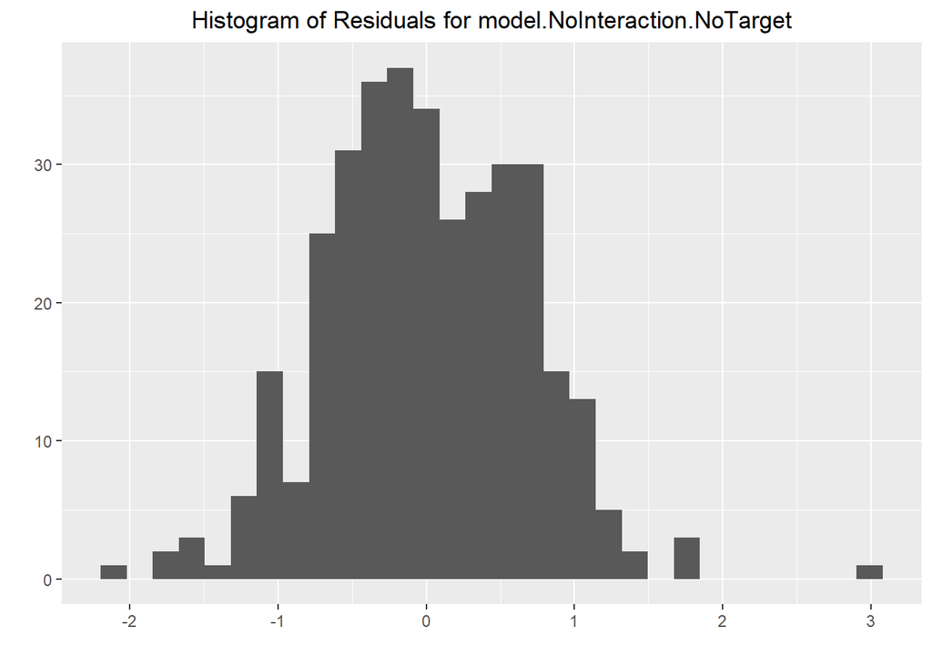

```r
# Data to model
data_modified_ind <- ind_data %>%
  select(params$dependent_response_ind,
         Target,
         SessionOrder,
         Team,
         Player_ID) %>%
  mutate(sqrt.value = sqrt(ifelse(.data[[params$dependent_response_ind]] < 0, 0, .data[[params$dependent_response_ind]]))) # Some of the time remaining vaules are negative when the should be zero. I want to make sure those values are zero

# Plot location
setwd(figure_directory)

#response_variable <- "sqrt.value"
data_focus_ind <- data_modified_ind

# Generate models with variable response
model.NoInteraction.NoTarget <- model_data_Target_Session(df = data_focus_ind, dependent =  "sqrt.value", model.type =  "NoInteraction_NoTarget", is.team = FALSE, is.robust = FALSE)

# Histogram of Residuals - model.NoInteraction.NoTarget
ggplot(model.NoInteraction.NoTarget, aes(x = .resid)) +
  geom_histogram(bins = 30) +
  labs(title = paste("Histogram of Residuals for model.NoInteraction.NoTarget"), x = "", y = "") +
  theme(plot.title = element_text(hjust = 0.5)) +
  ggsave(paste("Histogram_Residuals_", params$dependent_response_name_NoSpace, "_sqrt_NoInteractionNoTarget_Ind.png", sep =""))
```

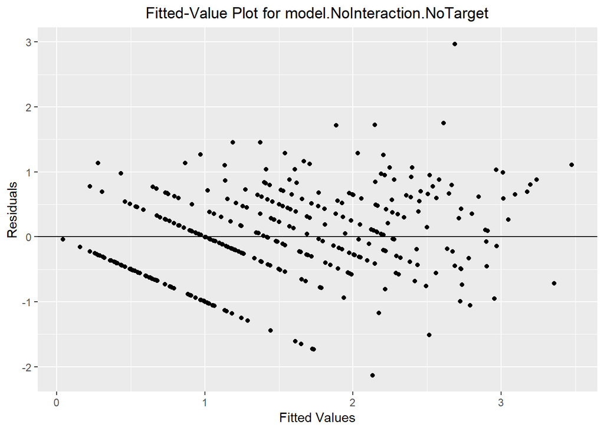

```r
# Fitted values - model.NoInteraction.NoTarget
ggplot(model.NoInteraction.NoTarget, aes(x = .fitted, y = .resid)) +
  geom_point() +
  geom_hline(yintercept = 0)+
  labs(title = paste("Fitted-Value Plot for model.NoInteraction.NoTarget"), x = "Fitted Values", y = "Residuals") +
  theme(plot.title = element_text(hjust = 0.5)) +
  ggsave(paste("FittedValue_Residuals_", params$dependent_response_name_NoSpace, "_sqrt_NoInteractionNoTarget_Ind.png", sep =""))
```

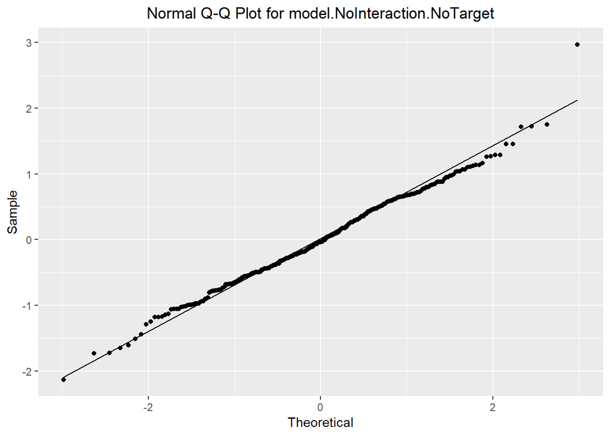

```r
# QQ plots - model.NoInteraction.NoTarget
ggplot(model.NoInteraction.NoTarget, aes(sample = .resid)) +
  stat_qq() +
  stat_qq_line()+
  labs(title = "Normal Q-Q Plot for model.NoInteraction.NoTarget", x = "Theoretical", y = "Sample") +
  theme(plot.title = element_text(hjust = 0.5)) +
  ggsave(paste("QQ_Residuals_", params$dependent_response_name_NoSpace, "_sqrt_NoInteractionNoTarget_Ind.png", sep =""))
```

The diagnostic plots suggest the transformation has resolved the assumption violations for the model.NoInteraction.

##### Q: Are there any effects that are significant?

###### model.NoInteraction

```r
# Data to model
data_modified_ind <- ind_data %>%
  select(params$dependent_response_ind,
         Target,
         SessionOrder,
         Team,
         Player_ID) %>%
  mutate(sqrt.value = sqrt(ifelse(.data[[params$dependent_response_ind]] < 0, 0, .data[[params$dependent_response_ind]]))) # Some fo the time remaining vaules are negative when the should be zero. I want to make sure those values are zero

#response_variable <- "sqrt.value"
data_focus_ind <- data_modified_ind

# Generate models with variable response
model.NoInteraction <- model_data_Target_Session(df = data_focus_ind, dependent =  "sqrt.value", model.type =  "NoInteraction", is.team = FALSE, is.robust = FALSE)

summary(model.NoInteraction)
```

```
## Linear mixed model fit by REML. t-tests use Satterthwaite's method [
## lmerModLmerTest]
## Formula:
## as.formula(paste(dependent, "~ Target + SessionOrder + (1|Team) + (1| Player_ID)"))
##    Data: df
##
## REML criterion at convergence: 931.1
##
## Scaled residuals:
##     Min      1Q  Median      3Q     Max
## -2.8861 -0.6153 -0.0500  0.6787  3.8911
##
## Random effects:
##  Groups    Name        Variance Std.Dev.
##  Player_ID (Intercept) 0.1214   0.3485
##  Team      (Intercept) 0.4713   0.6865
##  Residual              0.5672   0.7531
## Number of obs: 351, groups:  Player_ID, 117; Team, 39
##
## Fixed effects:
##                 Estimate Std. Error        df t value Pr(>|t|)
## (Intercept)      1.93335    0.14479  74.69827  13.352  < 2e-16 ***
## TargetInd_Team   0.03485    0.09860 229.99802   0.353    0.724
## TargetTeam      -0.05303    0.09850 229.99802  -0.538    0.591
## SessionOrder3   -0.51198    0.09850 229.99802  -5.198 4.45e-07 ***
## SessionOrder4   -0.75044    0.09860 229.99802  -7.611 6.96e-13 ***
## ---
## Signif. codes:  0 '***' 0.001 '**' 0.01 '*' 0.05 '.' 0.1 ' ' 1
##
## Correlation of Fixed Effects:
##             (Intr) TrgI_T TrgtTm SssnO3
## TargtInd_Tm -0.323
## TargetTeam  -0.332  0.500
## SessinOrdr3 -0.332 -0.026 -0.013
## SessinOrdr4 -0.323 -0.051 -0.026  0.500
```

The results show no significant effect from the Ind_Team or Team level in reference to the Ind level for the Target variable. The results show a significant effect from session 3 and 4 in reference to session 2.

```r
# Data to model
data_modified_ind <- ind_data %>%
  select(params$dependent_response_ind,
         Target,
         SessionOrder,
         Team,
         Player_ID) %>%
  mutate(sqrt.value = sqrt(ifelse(.data[[params$dependent_response_ind]] < 0, 0, .data[[params$dependent_response_ind]]))) # Some fo the time remaining vaules are negative when the should be zero. I want to make sure those values are zero

#response_variable <- "sqrt.value"
data_focus_ind <- data_modified_ind

# Generate models with variable response
model.NoInteraction <- model_data_Target_Session(df = data_focus_ind, dependent =  "sqrt.value", model.type =  "NoInteraction", is.team = FALSE, is.robust = FALSE)

emmeans(model.NoInteraction, list(pairwise ~ Target), adjust = "tukey")
```

```
## $`emmeans of Target`
##  Target   emmean    SE   df lower.CL upper.CL
##  Ind        1.51 0.134 56.1     1.24     1.78
##  Ind_Team   1.55 0.134 56.1     1.28     1.82
##  Team       1.46 0.134 56.0     1.19     1.73
##
## Results are averaged over the levels of: SessionOrder
## Degrees-of-freedom method: satterthwaite
## Confidence level used: 0.95
##
## $`pairwise differences of Target`
##  contrast        estimate     SE  df t.ratio p.value
##  Ind - Ind_Team   -0.0348 0.0986 230 -0.353  0.9335
##  Ind - Team        0.0530 0.0985 230  0.538  0.8525
##  Ind_Team - Team   0.0879 0.0985 230  0.892  0.6458
##
## Results are averaged over the levels of: SessionOrder
## P value adjustment: tukey method for comparing a family of 3 estimates
```

The results showed no significant difference among the Target levels.

```r
# Data to model
data_modified_ind <- ind_data %>%
  select(params$dependent_response_ind,
         Target,
         SessionOrder,
         Team,
         Player_ID) %>%
  mutate(sqrt.value = sqrt(ifelse(.data[[params$dependent_response_ind]] < 0, 0, .data[[params$dependent_response_ind]]))) # Some fo the time remaining vaules are negative when the should be zero. I want to make sure those values are zero

#response_variable <- "sqrt.value"
data_focus_ind <- data_modified_ind

# Generate models with variable response
model.NoInteraction <- model_data_Target_Session(df = data_focus_ind, dependent =  "sqrt.value", model.type =  "NoInteraction", is.team = FALSE, is.robust = FALSE)

emmeans(model.NoInteraction, list(pairwise ~ SessionOrder), adjust = "tukey")
```

```
## $`emmeans of SessionOrder`
##  SessionOrder emmean    SE   df lower.CL upper.CL
##  2              1.93 0.134 56.1    1.659     2.20
##  3              1.42 0.134 56.0    1.147     1.68
##  4              1.18 0.134 56.1    0.908     1.45
##
## Results are averaged over the levels of: Target
## Degrees-of-freedom method: satterthwaite
## Confidence level used: 0.95
##
## $`pairwise differences of SessionOrder`
##  contrast estimate     SE  df t.ratio p.value
##  2 - 3       0.512 0.0985 230 5.198   <.0001
##  2 - 4       0.750 0.0986 230 7.611   <.0001
##  3 - 4       0.238 0.0985 230 2.421   0.0428
##
## Results are averaged over the levels of: Target
## P value adjustment: tukey method for comparing a family of 3 estimates
```

The results show a significant difference among all of the session. Specifically, the results show that the number of totals rules broken decreases over time.

###### model.NoInteractionNoTarget

```r
# Data to model
data_modified_ind <- ind_data %>%
  select(params$dependent_response_ind,
         Target,
         SessionOrder,
         Team,
         Player_ID) %>%
  mutate(sqrt.value = sqrt(ifelse(.data[[params$dependent_response_ind]] < 0, 0, .data[[params$dependent_response_ind]]))) # Some fo the time remaining vaules are negative when the should be zero. I want to make sure those values are zero

#response_variable <- "sqrt.value"
data_focus_ind <- data_modified_ind

# Generate models with variable response
model.NoInteractionNoTarget <- model_data_Target_Session(df = data_focus_ind, dependent =  "sqrt.value", model.type =  "NoInteraction_NoTarget", is.team = FALSE, is.robust = FALSE)

summary(model.NoInteractionNoTarget)
```

```
## Linear mixed model fit by REML. t-tests use Satterthwaite's method [
## lmerModLmerTest]
## Formula:
## as.formula(paste(dependent, "~ SessionOrder + (1|Team) + (1| Player_ID)"))
##    Data: df
##
## REML criterion at convergence: 926
##
## Scaled residuals:
##     Min      1Q  Median      3Q     Max
## -2.8363 -0.6090 -0.0486  0.6598  3.9548
##
## Random effects:
##  Groups    Name        Variance Std.Dev.
##  Player_ID (Intercept) 0.1224   0.3499
##  Team      (Intercept) 0.4713   0.6865
##  Residual              0.5643   0.7512
## Number of obs: 351, groups:  Player_ID, 117; Team, 39
##
## Fixed effects:
##                Estimate Std. Error        df t value Pr(>|t|)
## (Intercept)     1.92640    0.13399  55.95309  14.377  < 2e-16 ***
## SessionOrder3  -0.51108    0.09821 232.00015  -5.204 4.29e-07 ***
## SessionOrder4  -0.74866    0.09821 232.00015  -7.623 6.32e-13 ***
## ---
## Signif. codes:  0 '***' 0.001 '**' 0.01 '*' 0.05 '.' 0.1 ' ' 1
##
## Correlation of Fixed Effects:
##             (Intr) SssnO3
## SessinOrdr3 -0.366
## SessinOrdr4 -0.366  0.500
```

The results show a significant effect from the sesson 3 and 4 in reference to session 2.

```r
# Data to model
data_modified_ind <- ind_data %>%
  select(params$dependent_response_ind,
         Target,
         SessionOrder,
         Team,
         Player_ID) %>%
  mutate(sqrt.value = sqrt(ifelse(.data[[params$dependent_response_ind]] < 0, 0, .data[[params$dependent_response_ind]]))) # Some fo the time remaining vaules are negative when the should be zero. I want to make sure those values are zero

#response_variable <- "sqrt.value"
data_focus_ind <- data_modified_ind

# Generate models with variable response
model.NoInteraction.NoTarget  <- model_data_Target_Session(df = data_focus_ind, dependent =  "sqrt.value", model.type =  "NoInteraction_NoTarget", is.team = FALSE, is.robust = FALSE)

emmeans(model.NoInteraction, list(pairwise ~ SessionOrder), adjust = "tukey")
```

```
## $`emmeans of SessionOrder`
##  SessionOrder emmean    SE   df lower.CL upper.CL
##  2              1.93 0.134 56.1    1.659     2.20
##  3              1.42 0.134 56.0    1.147     1.68
##  4              1.18 0.134 56.1    0.908     1.45
##
## Results are averaged over the levels of: Target
## Degrees-of-freedom method: satterthwaite
## Confidence level used: 0.95
##
## $`pairwise differences of SessionOrder`
##  contrast estimate     SE  df t.ratio p.value
##  2 - 3       0.512 0.0985 230 5.198   <.0001
##  2 - 4       0.750 0.0986 230 7.611   <.0001
##  3 - 4       0.238 0.0985 230 2.421   0.0428
##
## Results are averaged over the levels of: Target
## P value adjustment: tukey method for comparing a family of 3 estimates
```

The results show a significant effect among all of the sessions. Specifically, the total number of rules broken dereases over time.

##### Summary / Reflection

Overall, at the individual level, there were no unexpected significant results. No significant difference amount the Target levels indicates the intervention did not influence the total number of rules broken.

# References

Field, A. P., & Wilcox, R. R. (2017). Robust statistical methods: A primer for clinical psychology and experimental psychopathology researchers. *Behaviour Research and Therapy*, *98*, 19–38. https://doi.org/10.1016/j.brat.2017.05.013

Galwey, N. W. (2014). Testing the assumptions of the analyses: Inspection of the residual values. In *Introduction to mixed modelling: Beyond regression and analysis of variance* (Second). Chichester, United Kingdom: John Wiley & Sons, Ltd.

Johnson, P. C. (2014). Extension of Nakagawa & Schielzeth’s R 2 GLMM to random slopes models. *Methods in Ecology and Evolution*, *5*(9), 944–946. https://doi.org/10.1111/2041-210X.12225

Koller, M. (2016). robustlmm : An R Package for Robust Estimation of Linear Mixed-Effects Models. *Journal of Statistical Software*, *75*(6). https://doi.org/10.18637/jss.v075.i06

Nakagawa, S., & Schielzeth, H. (2013). A general and simple method for obtaining R 2 from generalized linear mixed-effects models. *Methods in Ecology and Evolution*, *4*(2), 133–142. https://doi.org/10.1111/j.2041-210x.2012.00261.x

Tukey, J. W. (1977). *Exploratory data analysis*. Reading, Mass.: Addison-Wesley Pub.